# Methods for Data Science: Course Work 2

```python
import numpy as np
import pandas as pd
import matplotlib.pyplot as plt
import scipy as sc
from scipy.sparse import linalg
from scipy.stats import multivariate_normal
from matplotlib.patches import Ellipse
```

# Task 1: Neural Networks, Dimensionality Reduction and Mixture Models (65 marks)

## Prepare Data

Let us first start by loading in our data.

```python
# read in data using pandas
MNIST_train = pd.read_csv('MNIST_train.csv')
MNIST_test = pd.read_csv('MNIST_test.csv')
MNIST_train_noisy = pd.read_csv('mnist_train_noisy.txt', sep=" ", header=None)
MNIST_test_noisy = pd.read_csv('mnist_test_noisy.txt', sep=" ", header=None)
```

Now we create functions to standardise and normalise our data for PCA and NMF.

```python
# standardise data for PCA
def standardise(X):
    mu = np.mean(X, axis=0)
    std = np.std(X, axis=0)
    std_filled = std.copy()
    std_filled[std==0] = 1.
    Xbar = ((X-mu)/std_filled)
    return Xbar, mu, std

# normalise each element to a value between 0 and 1 for NMF
def normalise_nmf(X):
    return (X-np.min(X))/(np.max(X)-np.min(X))
```

Now we can prepare our data by dividing them by 255 to avoid overflow error, creating batches for the MLP and normalising and standardising for dimensionality reduction.

```python
# convert predictor and target variables to numpy array
x_train = MNIST_train.iloc[:, 1:].to_numpy()
y_train = MNIST_train.loc[:,'label'].to_numpy()
x_test = MNIST_test.iloc[:, 1:].to_numpy()
y_test = MNIST_test.loc[:,'label'].to_numpy()
x_train_noisy = MNIST_train_noisy.to_numpy()
x_test_noisy = MNIST_test_noisy.to_numpy()

# divide by 255 to avoid overflow error
x_train = x_train/255
x_test = x_test/255
x_train_noisy = x_train_noisy/255
x_test_noisy = x_test_noisy/255

# standardise data for PCA
x_train_pca = standardise(x_train)[0]

# create batches for MLP
x_train_batch = np.array_split(x_train[:5888,:], 46)
x_train_batch.append(x_train[5888:,:])

y_train_batch = np.array_split(y_train[:5888], 46)
y_train_batch.append(y_train[5888:])

# noisy data for PCA
x_train_noisy_pca,  x_train_noisy_pca_mu, x_train_noisy_pca_std = standardise(x_train_noisy)
x_test_noisy_pca = (x_test_noisy - x_train_noisy_pca_mu)/x_train_noisy_pca_std

# noisy data for NMF
x_train_noisy_nmf = normalise_nmf(x_train_noisy)
x_test_noisy_nmf = normalise_nmf(x_test_noisy)
```

# 1.1 Multi-Layer Perceptron (MLP) (25 marks)

## 1.1.1

We will implement a multi-layer pereceptron (MLP) with an input layer of 784 (28 x 28) units, 3 hidden layers (with 200 neurons each) followed by an output layer with 10 neurons. In between our layers we will use the $\mathbf{\text{softplus}}$ activation function with $\beta=1$ and the $\mathbf{\text{softmax}}$ function as our activation function on our output layer. We will use $\mathbf{\text{stochastic gradient descent (SGD)}}$ as our optimisation method and adopt the $\mathbf{\text{KL divergence}}$ as our loss function. After building our model we will train our model on the training set in batches of 128 data points for 40 epochs varying our learning rate between $10^{-5}$ to $10^{-1}$.

Our model will be used to classify input images representing digits from 0 to 9 and output a digit from 0 to 9 with the highest probability of being the correct digit.

Before we start we will create a function to one-hot encode our target variables as we wish to transform our categorical variable to numerical.

```python
def one_hot(y, num_classes=10):
    """
    Converts a vector of labels to a one-hot encoded matrix

    Args:
        y: vector of labels
        num_classes: number of classes

    Returns:
        one-hot encoded matrix
    """
    return np.eye(num_classes)[y]
```

Now let us define `dense` which implements the affine transfomation of our dense layers given weight and bias parameters, returning the pre-activation layer.

```python
def dense(X, W, b):
    return b + X @ W.T
```

Now we can define our `softplus` activation function for our hidden layers. Using softplus as our activation function ensures our outputs are always positive but is also monotonic and differentiable, a benefit when using gradient-based optimisation. The softplus function is defined as,

$$ \text{softplus}(x) = \frac{\log \left( 1 + e^{\beta x } \right)}{\beta}. $$

In our model we will use $\beta = 1$.

```python
def softplus(X, beta=1):
    return np.log(1 + np.exp(beta * X)) / beta
```

Next we will define our `softmax` function for our output layer. The softmax function serves a way to produce a probability distribution for classifying our images and since it is differentiable it enables us to use stochastic gradient descent. The softmax function is defined as,

$$ \text{softamx}(\mathbf{X})_i = \frac{e^{x_i}}{\sum_{j=1}^{n} e^{x_j}}. $$

```python
def softmax(X):
    return np.exp(X) / np.sum(np.exp(X), axis=1, keepdims=True)
```

Our model will require weight and biases parameters these will have the following structure:

Input layer -> first hidden layer:

- Kernel $\boldsymbol{W}^{(0)} \in\mathbb{R}^{784\times 200}$
- Bias $\boldsymbol{b}^{(0)} \in\mathbb{R}^{200}$

Hidden layer -> hidden layer:

- Kernel $\boldsymbol{W}^{(k)} \in\mathbb{R}^{200\times 200}$, $k=1, 2$
- Bias $\boldsymbol{b}^{(k)} \in\mathbb{R}^{200}$, $k=1, 2$

Hidden layer -> output layer:

- Kernel $\boldsymbol{W}^{(3)} \in\mathbb{R}^{200\times 10}$
- Bias $\boldsymbol{b}^{(3)} \in\mathbb{R}^{10}$

We will initiliase our parameters using Glorot Initialisation where we initialise the kernel with samples from a zero-mean Gaussian distribution with variance $2 / (n_{in} + n_{out})$, where $n_{in}$ and $n_{out}$ are the number of neurons going in and out of the dense layer respectively and we initialise the bias parameters to 0.

```python
def glorotInitalise(num_input, hidden_neurons, num_output):

    var0 = 2/(hidden_neurons + num_input)
    W0 = np.random.randn(hidden_neurons, num_input) * np.sqrt(var0)
    b0 = np.zeros(hidden_neurons)

    var1 = 2/(hidden_neurons + hidden_neurons)
    W1 = np.random.randn(hidden_neurons, hidden_neurons) * np.sqrt(var1)
    b1 = np.zeros(hidden_neurons)

    var2 = 2/(hidden_neurons + hidden_neurons)
    W2 = np.random.randn(hidden_neurons, hidden_neurons) * np.sqrt(var2)
    b2 = np.zeros(hidden_neurons)

    var3 = 2/(num_output + hidden_neurons)
    W3 = np.random.randn(num_output, hidden_neurons) * np.sqrt(var3)
    b3 = np.zeros(num_output)

    return W0, b0, W1, b1, W2, b2, W3, b3
```

Now we can create our MLP model using `dense` and our parameters and `mlp` will return our predictions.

```python
def mlp(X, W0, b0, W1, b1, W2, b2, W3, b3):

    h = dense(X, W0, b0)
    h = softplus(h)
    h = dense(h, W1, b1)
    h = softplus(h)
    h = dense(h, W2, b2)
    h = softplus(h)
    h = dense(h, W3, b3)
    h = softmax(h)

    return h
```

Now that we have create our forward propagation segment of our MLP we now focus on the backpropagation portion of our model. Let us first implement our loss function, the KL divergence. The KL divergence is defined as

$$ L(y_{\text{true}}, y_{\text{pred}}) = y_{\text{true}} \cdot \log \left( \frac{y_{\text{true}}}{y_{\text{pred}}} \right) $$

We will use an pointwise implemenetation modified for one-hot encoding. Due to one-hot encoding we will have a 0 within $\log$ except for 1 case therefore our loss will read as $\log\left(1/y_{\text{pred}}\right)$.

```python
def kl_loss(y_true, y_pred):
    """
    Computes the KL divergence loss between two distributions

    Args:
        y_true: true distribution
        y_pred: predicted distribution

    Returns:
        KL divergence loss
    """

    # np.where returns the index of the element with value 1 in our one-hot encoded target variable
    idx = np.where(y_true == 1)
    return -np.log(y_pred[idx])
```

Backpropagation is an algorithm in supervised learning that uses gradient descent to train an MLP, it works by calculating the gradient of the error with respect to the weights, upating our parameters accordingly. We can summarise the backpropagation algorithm as follows:

1. Define our error for layer $k$ as $\delta^{(k)} _p = \frac{\partial L_i}{\partial a^{(k)}_p}$ where $i$ denotes the data point and the $p$-th activation in layer $k$
2. Then propagate our input vector $x_i$ forward through our network computing all pre and post-activations using $a^{(k)} = (h^{(k-1)})^{T} W^{(k-1)} + b^{(k-1)}$
3. Then evaluate $\delta^{(4)} = \frac{\partial L_i}{\partial a^{(4)}}$ for the output neuron
4. Backpropagate errors to compute $\delta^{(k)}$ for each hidden unit using $\delta^{(k)} = \sigma^{'}(a^{(k)}) W^{(k)} \delta^{(k+1)}$
5. Then we can obtain derivatives of $L_i$ with respect to weights and biases using $\frac{\partial L_i}{\partial w^{(k)} _{pq}} = \delta^{(k+1)} _p h^{(k)} _q$ and $\frac{\partial L_i}{\partial b^{(k)} _p} = \delta^{(k+1)} _p$

To implement backpropagation we first need to derive our `output error`,

$$ \delta^{(4)} = \frac{\partial L_i}{\partial a^{(4)}} = y_{\text{pred}} - y_{\text{true}}. $$

```python
def output_error(y_true, y_pred):
    return y_pred - y_true
```

Next we will need to calculate the derivative of our `softplus` function.

$$ \frac{d (\text{softplus(x))}}{dx} = \frac{d}{dx}\log \left( 1 + e^{x } \right) = \frac{1}{1 + e^{-x}}. $$

```python
def activation_derivative(X):
    return 1/(1 + np.exp(-X))
```

Given the output error $\delta^{(4)}$ we can create a function to backpropagate $\delta^{(4)}$ to obtain $\delta^{(3)}, \ \delta^{(2)} \ \text{and} \ \delta^{(1)}$ using our weight matrices and pre-activations.

```python
def backpropagate(delta, W, a):
    """
    Backpropagates our output error to obtain previous errors

    Args:
        delta: array of output error
        W: array of weights
        a: array of hidden layer pre-activations

    Returns:
        array hidden layer errors
    """
    return activation_derivative(a) * (delta @ W)
```

Finally given our errors and post-activations we can compute our gradient, derivative of $L_i$ with respect to our weights and biases. We can create a function `grads` which calculates the gradients averaged over the batch size.

```python
def grads(delta1, delta2, delta3, delta4, h0, h1, h2, h3):
    """
    Compute gradients of loss averaged over batchsize

    Args:
        delta1: array of hidden layer error
        delta2: array of hidden layer error
        delta3: array of hidden layer error
        delta4: array of output error
        h0: array of inputs
        h1: array of hidden layer post-activations
        h2: array of hidden layer post-activations
        h3: array of hidden layer post-activations

    Returns:
        tuple of arrays of gradients
    """
    # calculate gradients by using formula in Step 5
    grad_W0 = delta1[:, np.newaxis, :] * h0[:, :, np.newaxis]
    grad_b0 = delta1
    grad_W1 = delta2[:, np.newaxis, :] * h1[:, :, np.newaxis]
    grad_b1 = delta2
    grad_W2 = delta3[:, np.newaxis, :] * h2[:, :, np.newaxis]
    grad_b2 = delta3
    grad_W3 = delta4[:, np.newaxis, :] * h3[:, :, np.newaxis]
    grad_b3 = delta4

    # take average gradient over batchsize
    grad_W0 = np.mean(grad_W0, axis=0)
    grad_b0 = np.mean(grad_b0, axis=0)
    grad_W1 = np.mean(grad_W1, axis=0)
    grad_b1 = np.mean(grad_b1, axis=0)
    grad_W2 = np.mean(grad_W2, axis=0)
    grad_b2 = np.mean(grad_b2, axis=0)
    grad_W3 = np.mean(grad_W3, axis=0)
    grad_b3 = np.mean(grad_b3, axis=0)

    return grad_W0, grad_b0, grad_W1, grad_b1, grad_W2, grad_b2, grad_W3, grad_b3
```

Finally we will need to calculate the accuracy of our model which we will do by comparing our one-hot encoded target variable and the digit correpsonding to the output with the highest probability.

```python
def accuracy(x_test, y_test, W0, b0, W1, b1, W2, b2, W3, b3):
    y_pred = np.argmax(mlp(x_test, W0, b0, W1, b1, W2, b2, W3, b3), axis=1)
    return np.mean(y_pred == y_test)
```

We can finally have the necessary functions needed to compile the MLP model. We first initialise our weight matrices and bias vectors. Then we loop over through each epoch shuffling our batches and passing it through our forward pass. After each batch we compute the prediction error and backpropagate, finding the errors of each pre-activation layer respectively. Then we compute the gradient of the parameters and use the SGD algorithm to minimise the loss. Then we input the entire training set into our network with the updated parameters to obtain the loss and accuracy of our model.

```python
def multiLayerPerceptron(x_train_batch, y_train_batch, epochs, learning_rate, num_input, num_neuron, num_ouput, prt=False):

    # initialise parameters
    W0, b0, W1, b1, W2, b2, W3, b3 = glorotInitalise(num_input, num_neuron, num_ouput)

    # empty list to store loss and accuracy of training data
    loss_train = []
    acc_train = []

    # empty list to store loss and accuracy of testing data
    loss_test = []
    acc_test = []

    # get length of batched data then shuffle batch
    num_batches = len(x_train_batch)
    idx = np.arange(num_batches)

    # loop over epochs
    for epoch in range(epochs):

        # shuffle batch each epoch
        np.random.shuffle(idx)
        x_train_batch = np.array(x_train_batch, dtype=object)[idx]
        y_train_batch = np.array(y_train_batch, dtype=object)[idx]

        # loop over mini-batches of training data
        for x_batch, y_batch in zip(x_train_batch, y_train_batch):

            # one-hot encode output data
            y_batch = one_hot(y_batch)

            # forward pass (3 hidden layers)
            a1 = dense(x_batch, W0, b0) # pre-activation
            h1 = softplus(a1) # post-activation
            a2 = dense(h1, W1, b1)
            h2 = softplus(a2)
            a3 = dense(h2, W2, b2)
            h3 = softplus(a3)
            a4 = dense(h3, W3, b3)
            y_hat = softmax(a4) # output activation returns probability distribution

            # backward pass (backpropagation)
            delta4 = output_error(y_batch, y_hat) # output error
            delta3 = backpropagate(delta4, W3, a3) # hidden layer error
            delta2 = backpropagate(delta3, W2, a2)
            delta1 = backpropagate(delta2, W1, a1)

            var_grads = grads(delta1, delta2, delta3, delta4, x_batch, h1, h2, h3)

            # stochastic gradient descent (SGD) update
            W0 = W0 - learning_rate * var_grads[0].T
            b0 = b0 - learning_rate * var_grads[1].T
            W1 = W1 - learning_rate * var_grads[2].T
            b1 = b1 - learning_rate * var_grads[3].T
            W2 = W2 - learning_rate * var_grads[4].T
            b2 = b2 - learning_rate * var_grads[5].T
            W3 = W3 - learning_rate * var_grads[6].T
            b3 = b3 - learning_rate * var_grads[7].T

        # store loss and accuracy of entire train and test
        l_train = np.mean(kl_loss(one_hot(y_train), mlp(x_train, W0, b0, W1, b1, W2, b2, W3, b3)))
        l_test = np.mean(kl_loss(one_hot(y_test), mlp(x_test, W0, b0, W1, b1, W2, b2, W3, b3)))

        a_train = accuracy(x_train, y_train, W0, b0, W1, b1, W2, b2, W3, b3)
        a_test = accuracy(x_test, y_test, W0, b0, W1, b1, W2, b2, W3, b3)

        # print out performance after each epoch to track progress
        if prt == True:
            print(f"Epoch {epoch+1} \n Training loss: {l_train}, Test loss: {l_test}, Training accuracy: {a_train}, Test accuracy: {a_test}")

        # append loss
        loss_train.append(l_train)
        loss_test.append(l_test)

        # append accuracy
        acc_train.append(a_train)
        acc_test.append(a_test)

    return loss_train, loss_test, acc_train, acc_test, W0, b0
```

Using the training set we can train our MLP on batches of 128 data points for 40 epochs over learning rates varying from $10^{-5}$ to $10^{-1}$. We will then record the final loss achieved for each learning rate and plot it as a function of the learning rate.

```python
# calculate final loss for different learning rates
learning_rates = [1e-1, 1e-2, 1e-3, 1e-4, 1e-5]
final_loss = [] # store final loss
for lr in learning_rates:
    print(f'Learning rate: {lr}')
    final_loss.append(multiLayerPerceptron(x_train_batch, y_train_batch, 40, lr, 784, 200, 10, prt=True)[0][-1])
```

```
Learning rate: 0.1
Epoch 1
 Training loss: 1.983286163968678, Test loss: 1.9730277966453347, Training accuracy: 0.3315, Test accuracy: 0.333
Epoch 2
 Training loss: 1.262377337894605, Test loss: 1.2423479258894994, Training accuracy: 0.6286666666666667, Test accuracy: 0.626
Epoch 3
 Training loss: 1.4763889867273914, Test loss: 1.4520872229524153, Training accuracy: 0.6048333333333333, Test accuracy: 0.632
Epoch 4
 Training loss: 0.6996678758528089, Test loss: 0.6676261081842616, Training accuracy: 0.7728333333333334, Test accuracy: 0.772
Epoch 5
 Training loss: 0.5187229978524548, Test loss: 0.4798390140473223, Training accuracy: 0.8395, Test accuracy: 0.85
Epoch 6
 Training loss: 0.5191341922290995, Test loss: 0.4993016837064813, Training accuracy: 0.8318333333333333, Test accuracy: 0.844
Epoch 7
 Training loss: 0.4883624506654464, Test loss: 0.44870003453275537, Training accuracy: 0.8486666666666667, Test accuracy: 0.862
Epoch 8
 Training loss: 0.4780688939125918, Test loss: 0.4712365132921297, Training accuracy: 0.8393333333333334, Test accuracy: 0.845
Epoch 9
 Training loss: 0.3856566045496792, Test loss: 0.379480220325602, Training accuracy: 0.8848333333333334, Test accuracy: 0.879
Epoch 10
 Training loss: 0.37006565021414667, Test loss: 0.36446393378287983, Training accuracy: 0.8893333333333333, Test accuracy: 0.882
Epoch 11
 Training loss: 0.3320156199085407, Test loss: 0.33532262828365517, Training accuracy: 0.901, Test accuracy: 0.897
Epoch 12
 Training loss: 0.32399424611313765, Test loss: 0.31552329012004215, Training accuracy: 0.9036666666666666, Test accuracy: 0.909
Epoch 13
 Training loss: 0.2908151519753037, Test loss: 0.29171942963369135, Training accuracy: 0.9116666666666666, Test accuracy: 0.91
Epoch 14
 Training loss: 0.2977621989093487, Test loss: 0.29767927408941125, Training accuracy: 0.9071666666666667, Test accuracy: 0.909
Epoch 15
 Training loss: 0.37830622995062557, Test loss: 0.4142112172792974, Training accuracy: 0.8845, Test accuracy: 0.88
Epoch 16
 Training loss: 0.25404696030344526, Test loss: 0.26445916368576255, Training accuracy: 0.9245, Test accuracy: 0.923
Epoch 17
 Training loss: 0.2597121272189685, Test loss: 0.28470481658955665, Training accuracy: 0.921, Test accuracy: 0.915
Epoch 18
 Training loss: 0.25315779567682106, Test loss: 0.27348460766933047, Training accuracy: 0.9198333333333333, Test accuracy: 0.915
Epoch 19
 Training loss: 0.2813580984834896, Test loss: 0.27908393998685854, Training accuracy: 0.9118333333333334, Test accuracy: 0.911
Epoch 20
```

[output cut: 350 more lines]

```
 Training loss: 2.5842697135918318, Test loss: 2.5843847466876686, Training accuracy: 0.1, Test accuracy: 0.1
Epoch 34
 Training loss: 2.575310237137955, Test loss: 2.5754114724052806, Training accuracy: 0.1, Test accuracy: 0.1
Epoch 35
 Training loss: 2.5667465776755685, Test loss: 2.5668348260464153, Training accuracy: 0.1, Test accuracy: 0.1
Epoch 36
 Training loss: 2.5585566114176133, Test loss: 2.558632637152711, Training accuracy: 0.1, Test accuracy: 0.1
Epoch 37
 Training loss: 2.5507184510943843, Test loss: 2.550782966932692, Training accuracy: 0.1, Test accuracy: 0.1
Epoch 38
 Training loss: 2.543209324857009, Test loss: 2.5432629982366572, Training accuracy: 0.1, Test accuracy: 0.1
Epoch 39
 Training loss: 2.5360129536844234, Test loss: 2.536056410541524, Training accuracy: 0.1, Test accuracy: 0.1
Epoch 40
 Training loss: 2.5291137528346797, Test loss: 2.529147588027073, Training accuracy: 0.1, Test accuracy: 0.1
```

Let us visualise the final loss against the learning rate.

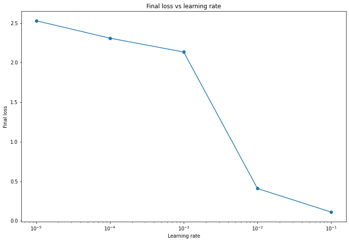

```python
plt.figure(figsize=(12, 8))
plt.plot(learning_rates, final_loss, 'o-')
plt.xscale('log')
plt.xlabel('Learning rate')
plt.ylabel('Final loss')
plt.title('Final loss vs learning rate')
plt.show()
```

Overall we see that as the learning rate increases the final loss of the MLP on the training set decreases. We note a steep decrease between learning rates $10^{-3}$ and $10^{-2}$. However, we will set our learning rate to be $10^{-1}$.

## 1.1.2

Now we have trained our MLP on a range of learning rates we will retrain our MLP on the optimal learning rate using batches of 128 data points and 40 epochs.

```python
loss_train_112, loss_test_112, accuracy_train_112, accuracy_test_112, W112, b112 = multiLayerPerceptron(x_train_batch, y_train_batch, 40, 1e-1, 784, 200, 10, prt=True)
```

```
Epoch 1
 Training loss: 2.089164017535997, Test loss: 2.073798964759154, Training accuracy: 0.20733333333333334, Test accuracy: 0.216
Epoch 2
 Training loss: 1.1305138732733238, Test loss: 1.0913460403668265, Training accuracy: 0.6646666666666666, Test accuracy: 0.685
Epoch 3
 Training loss: 1.0020750142692374, Test loss: 0.9852263245724655, Training accuracy: 0.6555, Test accuracy: 0.654
Epoch 4
 Training loss: 0.6472043790944227, Test loss: 0.63251741436626, Training accuracy: 0.7725, Test accuracy: 0.762
Epoch 5
 Training loss: 0.6488655542522269, Test loss: 0.6380040326401564, Training accuracy: 0.777, Test accuracy: 0.79
Epoch 6
 Training loss: 0.5192513237136097, Test loss: 0.4984079531864207, Training accuracy: 0.8251666666666667, Test accuracy: 0.83
Epoch 7
 Training loss: 0.44313627319914123, Test loss: 0.42725623615778807, Training accuracy: 0.8636666666666667, Test accuracy: 0.866
Epoch 8
 Training loss: 0.44264981652373914, Test loss: 0.41910053091450356, Training accuracy: 0.8508333333333333, Test accuracy: 0.861
Epoch 9
 Training loss: 0.3809221278907533, Test loss: 0.3743095875380583, Training accuracy: 0.8853333333333333, Test accuracy: 0.889
Epoch 10
 Training loss: 0.3326083542361524, Test loss: 0.320760148953794, Training accuracy: 0.903, Test accuracy: 0.901
Epoch 11
 Training loss: 0.3263238996204539, Test loss: 0.32601075273688457, Training accuracy: 0.9043333333333333, Test accuracy: 0.907
Epoch 12
 Training loss: 0.30267983065129406, Test loss: 0.2933108246354098, Training accuracy: 0.9115, Test accuracy: 0.912
Epoch 13
 Training loss: 0.3147664033026036, Test loss: 0.3180246660225434, Training accuracy: 0.9061666666666667, Test accuracy: 0.895
Epoch 14
 Training loss: 0.33988811058988705, Test loss: 0.32648176350284475, Training accuracy: 0.8863333333333333, Test accuracy: 0.898
Epoch 15
 Training loss: 0.3206661703366006, Test loss: 0.3335084476617544, Training accuracy: 0.9043333333333333, Test accuracy: 0.898
Epoch 16
 Training loss: 0.31316591581876774, Test loss: 0.30760435945455467, Training accuracy: 0.898, Test accuracy: 0.898
Epoch 17
 Training loss: 0.2692124145944953, Test loss: 0.28271474744673897, Training accuracy: 0.9181666666666667, Test accuracy: 0.91
Epoch 18
 Training loss: 0.24606904488500259, Test loss: 0.2564199595331046, Training accuracy: 0.9248333333333333, Test accuracy: 0.92
Epoch 19
 Training loss: 0.30511845344750826, Test loss: 0.316321115833366, Training accuracy: 0.9041666666666667, Test accuracy: 0.902
Epoch 20
 Training loss: 0.2305395115814577, Test loss: 0.2577302895700055, Training accuracy: 0.9276666666666666, Test accuracy: 0.927
```

[output cut: 25 more lines]

```
 Training loss: 0.23411510255450402, Test loss: 0.30583459335030194, Training accuracy: 0.9131666666666667, Test accuracy: 0.895
Epoch 34
 Training loss: 0.1495655772851595, Test loss: 0.22199686463361398, Training accuracy: 0.951, Test accuracy: 0.932
Epoch 35
 Training loss: 0.16402560042226355, Test loss: 0.24824944239727761, Training accuracy: 0.9455, Test accuracy: 0.915
Epoch 36
 Training loss: 0.15926323452699068, Test loss: 0.2408586669130785, Training accuracy: 0.9468333333333333, Test accuracy: 0.932
Epoch 37
 Training loss: 0.1374742755696451, Test loss: 0.21607294219719891, Training accuracy: 0.9566666666666667, Test accuracy: 0.934
Epoch 38
 Training loss: 0.21170521559931002, Test loss: 0.29642713909363966, Training accuracy: 0.929, Test accuracy: 0.912
Epoch 39
 Training loss: 0.13267103093868465, Test loss: 0.21757899295644376, Training accuracy: 0.9561666666666667, Test accuracy: 0.937
Epoch 40
 Training loss: 0.144131978389699, Test loss: 0.2488967121230685, Training accuracy: 0.952, Test accuracy: 0.927
```

Let us plot the loss and accuracy of the MLP as a function of the number of epochs for both the training and test sets.

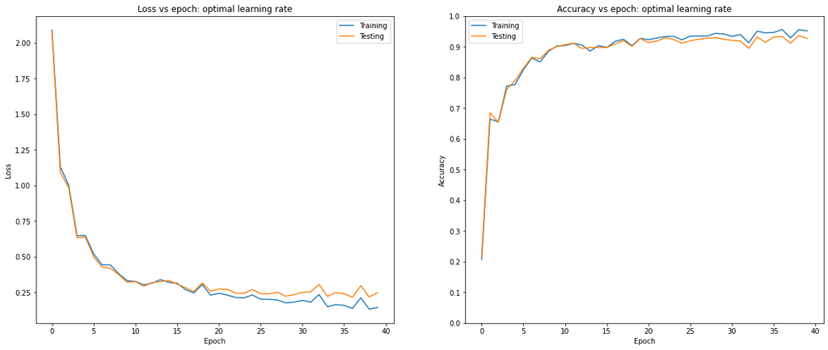

```python
plt.figure(figsize=(20,8))

plt.subplot(1,2,1)
plt.plot(loss_train_112)
plt.plot(loss_test_112)
plt.xlabel('Epoch')
plt.ylabel('Loss')
plt.title('Loss vs epoch: optimal learning rate')
plt.legend(['Training', 'Testing'])

plt.subplot(1,2,2)
plt.plot(accuracy_train_112)
plt.plot(accuracy_test_112)
plt.xlabel('Epoch')
plt.ylabel('Accuracy')
plt.yticks(np.arange(0, 1.1, 0.1))
plt.title('Accuracy vs epoch: optimal learning rate')
plt.legend(['Training', 'Testing'])
plt.show()
```

We see in both plots that the training set has both a lower final loss and higher final accuracy as expected, however we notice that both lines are close to each for each epoch. This suggests that our model performs well since we can see from the training set that our model learns well and from the testing set that our model generalises well. These results suggest that this model does not exhibit over nor under fitting.

## 1.1.3

Our results from 1.1.2 are promising however let us investigate different hyper-parameters and regularisation.

With our optimal learning rate, let us reduce the number of neurons in our hidden layer from 200 to 50 and see how this affects our performance.

```python
loss_train_113, loss_test_113, accuracy_train_113, accuracy_test_113, _, _ = multiLayerPerceptron(x_train_batch, y_train_batch, 40, 1e-1, 784, 50, 10, prt=True)
```

```
Epoch 1
 Training loss: 1.9881650082153464, Test loss: 1.988279882832986, Training accuracy: 0.3621666666666667, Test accuracy: 0.378
Epoch 2
 Training loss: 1.217644741431115, Test loss: 1.1918304547208034, Training accuracy: 0.5748333333333333, Test accuracy: 0.582
Epoch 3
 Training loss: 0.6189061228646298, Test loss: 0.6032550664131925, Training accuracy: 0.8085, Test accuracy: 0.81
Epoch 4
 Training loss: 0.5813144911406315, Test loss: 0.560069293605972, Training accuracy: 0.8046666666666666, Test accuracy: 0.8
Epoch 5
 Training loss: 0.4621724565395028, Test loss: 0.44464138906860806, Training accuracy: 0.8583333333333333, Test accuracy: 0.857
Epoch 6
 Training loss: 0.4179284145127516, Test loss: 0.4084088130601133, Training accuracy: 0.8753333333333333, Test accuracy: 0.881
Epoch 7
 Training loss: 0.5887215375295376, Test loss: 0.591559636168075, Training accuracy: 0.8026666666666666, Test accuracy: 0.801
Epoch 8
 Training loss: 0.3498024851012653, Test loss: 0.35354242878972947, Training accuracy: 0.8985, Test accuracy: 0.891
Epoch 9
 Training loss: 0.3155032865570357, Test loss: 0.31460621601461464, Training accuracy: 0.9038333333333334, Test accuracy: 0.908
Epoch 10
 Training loss: 0.30407996372029067, Test loss: 0.32150964875147464, Training accuracy: 0.9108333333333334, Test accuracy: 0.902
Epoch 11
 Training loss: 0.3025741217356218, Test loss: 0.31446669249607595, Training accuracy: 0.9075, Test accuracy: 0.897
Epoch 12
 Training loss: 0.3005587774850774, Test loss: 0.3156123428979576, Training accuracy: 0.907, Test accuracy: 0.904
Epoch 13
 Training loss: 0.2617628121303139, Test loss: 0.2971188667602033, Training accuracy: 0.9231666666666667, Test accuracy: 0.906
Epoch 14
 Training loss: 0.25734447294866514, Test loss: 0.27427388152880905, Training accuracy: 0.9196666666666666, Test accuracy: 0.907
Epoch 15
 Training loss: 0.2545149432263198, Test loss: 0.2747743704247943, Training accuracy: 0.9195, Test accuracy: 0.917
Epoch 16
 Training loss: 0.2381757128321185, Test loss: 0.26437812950112527, Training accuracy: 0.9296666666666666, Test accuracy: 0.92
Epoch 17
 Training loss: 0.25351080745465887, Test loss: 0.281610978340178, Training accuracy: 0.9146666666666666, Test accuracy: 0.904
Epoch 18
 Training loss: 0.2219818871048706, Test loss: 0.26113681810254036, Training accuracy: 0.9275, Test accuracy: 0.922
Epoch 19
 Training loss: 0.2138915734519293, Test loss: 0.25260317775213975, Training accuracy: 0.934, Test accuracy: 0.922
Epoch 20
 Training loss: 0.19448759534952378, Test loss: 0.24379685318038657, Training accuracy: 0.9396666666666667, Test accuracy: 0.92
```

[output cut: 25 more lines]

```
 Training loss: 0.11387601509983707, Test loss: 0.2259158761783973, Training accuracy: 0.9638333333333333, Test accuracy: 0.933
Epoch 34
 Training loss: 0.09252244709198439, Test loss: 0.20635747075094577, Training accuracy: 0.9746666666666667, Test accuracy: 0.934
Epoch 35
 Training loss: 0.1020557940054119, Test loss: 0.22104780322968373, Training accuracy: 0.969, Test accuracy: 0.929
Epoch 36
 Training loss: 0.14288442804650967, Test loss: 0.2673604425894319, Training accuracy: 0.9501666666666667, Test accuracy: 0.915
Epoch 37
 Training loss: 0.09716045204346686, Test loss: 0.23678020218927068, Training accuracy: 0.9703333333333334, Test accuracy: 0.93
Epoch 38
 Training loss: 0.08166203725190081, Test loss: 0.21948044109919168, Training accuracy: 0.9778333333333333, Test accuracy: 0.935
Epoch 39
 Training loss: 0.07214988284594588, Test loss: 0.2089474843578905, Training accuracy: 0.9806666666666667, Test accuracy: 0.941
Epoch 40
 Training loss: 0.0936798242374069, Test loss: 0.24719487430653517, Training accuracy: 0.9693333333333334, Test accuracy: 0.926
```

Let's plot the loss and accuracy of our model on the training and test set.

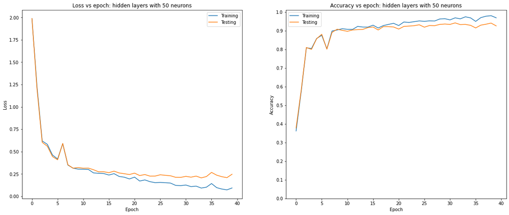

```python
plt.figure(figsize=(20, 8))

plt.subplot(1,2,1)
plt.plot(loss_train_113)
plt.plot(loss_test_113)
plt.xlabel('Epoch')
plt.ylabel('Loss')
plt.title('Loss vs epoch: hidden layers with 50 neurons')
plt.legend(['Training', 'Testing'])

plt.subplot(1,2,2)
plt.plot(accuracy_train_113)
plt.plot(accuracy_test_113)
plt.xlabel('Epoch')
plt.ylabel('Accuracy')
plt.yticks(np.arange(0, 1.1, 0.1))
plt.title('Accuracy vs epoch: hidden layers with 50 neurons')
plt.legend(['Training', 'Testing'])

plt.show()
```

Overall we see the gap between the lossess and accuracies begin to diverge from each other after around 10 epochs and carry on diverging. At the end there is a considerable gap between lines compared to the results in 1.1.2, this behaviour suggests that our model is not good at generalising the data that is with less neurons our model overfits the data (insufficient number of neurons to capture data).

Interestingly we see that for the loss on the training data, model 1.1.3 achieves an overall smaller loss than model 1.1.2, however, the loss on the testing data is roughly the same as 1.1.2. In terms of accuracy on the training data model 1.1.3 achieves a higher accuracy in general than 1.1.2 but on the testing data the values are similar to that of 1.1.2. These results suggest that even though 1.1.3 may perform better in terms of metrics it might be more suitbale to use 1.1.2 due to the overfitting behaviour of 1.1.3.

## 1.1.4

Next we will modify our original model by including a dropout at each hidden layer, scaling the output of each neuron in the hidden layer to compensate for the dropout. Dropout is a regularisation technique for neural networks which randomly set connections between weights to 0 (zero out neurons) according to a Bernoulli distribution. One of the main reasons for dropout is that it reduces the behaviour of neurons co-adapting therefore neurons begin to learn features that a more robust and therefore reducing overfitting. In our model we will apply dropout during the training phase and when making predictions all weight connections will be restored and appropiately rescaled. We will utilise `inverted dropout` and will rescale in the backpropagation pass.

```python
def multiLayerPerceptronDropout(x_train_batch, y_train_batch, epochs, learning_rate, num_input, num_neuron, num_ouput, p, prt=False):

    # initialise weight and bias
    W0, b0, W1, b1, W2, b2, W3, b3 = glorotInitalise(num_input, num_neuron, num_ouput)

    # lists to store loss and accuracy of training
    loss_train = []
    acc_train = []

    # lists to store loss and accuracy of testing
    loss_test = []
    acc_test = []

    # number of batches in training data
    num_batches = len(x_train_batch)
    idx = np.arange(num_batches)

    # loop for epochs
    for epoch in range(epochs):

        # shuffle the batches
        np.random.shuffle(idx)
        x_train_batch = np.array(x_train_batch, dtype=object)[idx]
        y_train_batch = np.array(y_train_batch, dtype=object)[idx]

        # loop for batches
        for x_batch, y_batch in zip(x_train_batch, y_train_batch):

            # one hot encoding
            y_batch = one_hot(y_batch)

            # forward pass (3 hidden layers) with dropout
            a1 = dense(x_batch, W0, b0)
            h1 = softplus(a1)
            U1 = np.random.binomial(1, 1-p, size=h1.shape) / (1-p) # first dropout mask
            h1 = h1 * U1
            a2 = dense(h1, W1, b1)
            h2 = softplus(a2)
            U2 = np.random.binomial(1, 1-p, size=h2.shape) / (1-p)
            h2 = h2 * U2
            a3 = dense(h2, W2, b2)
            h3 = softplus(a3)
            U3 = np.random.binomial(1, 1-p, size=h3.shape) / (1-p)
            h3 = h3 * U3
            a4 = dense(h3, W3, b3)
            y_hat = softmax(a4)

            # backpropagation with rescaling
            delta4 = output_error(y_batch, y_hat)
            delta3 = backpropagate(delta4, W3, a3)
            delta3 = delta3 * U3 # rescale back
            delta2 = backpropagate(delta3, W2, a2)
            delta2 = delta2 * U2
            delta1 = backpropagate(delta2, W1, a1)
            delta1 = delta1 * U1

            # calculate gradients
            var_grads = grads(delta1, delta2, delta3, delta4, x_batch, h1, h2, h3)

            # sgd update
            W0 = W0 - learning_rate * var_grads[0].T
            b0 = b0 - learning_rate * var_grads[1].T
            W1 = W1 - learning_rate * var_grads[2].T
            b1 = b1 - learning_rate * var_grads[3].T
            W2 = W2 - learning_rate * var_grads[4].T
            b2 = b2 - learning_rate * var_grads[5].T
            W3 = W3 - learning_rate * var_grads[6].T
            b3 = b3 - learning_rate * var_grads[7].T

        # store loss and accuracy of entire train and test
        l_train = np.mean(kl_loss(one_hot(y_train), mlp(x_train, W0, b0, W1, b1, W2, b2, W3, b3)))
        l_test = np.mean(kl_loss(one_hot(y_test), mlp(x_test, W0, b0, W1, b1, W2, b2, W3, b3)))

        a_train = accuracy(x_train, y_train, W0, b0, W1, b1, W2, b2, W3, b3)
        a_test = accuracy(x_test, y_test, W0, b0, W1, b1, W2, b2, W3, b3)

        # print out performance after each epoch to track progress
        if prt:
            print(f"Epoch {epoch+1} \n Training loss: {l_train}, Test loss: {l_test}, Training accuracy: {a_train}, Test accuracy: {a_test}")

        # calculate loss
        loss_train.append(l_train)
        loss_test.append(l_test)

        # calculate accuracy
        acc_train.append(a_train)
        acc_test.append(a_test)

    return loss_train, loss_test, acc_train, acc_test, W0, b0
```

```python
loss_train_114, loss_test_114, accuracy_train_114, accuracy_test_114, W114_drop, b114_drop = multiLayerPerceptronDropout(x_train_batch, y_train_batch, 60, 0.5, 784, 200, 10, 0.2, prt=True)
```

```
Epoch 1
 Training loss: 2.254830560768399, Test loss: 2.25186378492382, Training accuracy: 0.1, Test accuracy: 0.1
Epoch 2
 Training loss: 2.056325956260674, Test loss: 2.0499640324144917, Training accuracy: 0.3403333333333333, Test accuracy: 0.342
Epoch 3
 Training loss: 1.3013829656555886, Test loss: 1.2797612864452481, Training accuracy: 0.5715, Test accuracy: 0.586
Epoch 4
 Training loss: 0.9773835577141146, Test loss: 0.9411648304316578, Training accuracy: 0.6438333333333334, Test accuracy: 0.659
Epoch 5
 Training loss: 0.8028466125324959, Test loss: 0.7836553399524842, Training accuracy: 0.7715, Test accuracy: 0.78
Epoch 6
 Training loss: 0.4274202547091346, Test loss: 0.4159411564680608, Training accuracy: 0.875, Test accuracy: 0.871
Epoch 7
 Training loss: 0.3814510132351587, Test loss: 0.3759469422770126, Training accuracy: 0.8798333333333334, Test accuracy: 0.882
Epoch 8
 Training loss: 0.3754498676241696, Test loss: 0.38029323149050226, Training accuracy: 0.8813333333333333, Test accuracy: 0.871
Epoch 9
 Training loss: 0.3168372069461929, Test loss: 0.3192885267873238, Training accuracy: 0.9005, Test accuracy: 0.901
Epoch 10
 Training loss: 0.32920706796978305, Test loss: 0.32441146585493913, Training accuracy: 0.8921666666666667, Test accuracy: 0.891
Epoch 11
 Training loss: 0.2760941598506927, Test loss: 0.2817753379044764, Training accuracy: 0.9115, Test accuracy: 0.916
Epoch 12
 Training loss: 0.26255369455100713, Test loss: 0.29042103979767103, Training accuracy: 0.9161666666666667, Test accuracy: 0.913
Epoch 13
 Training loss: 0.23299093456468467, Test loss: 0.2682138297191416, Training accuracy: 0.9271666666666667, Test accuracy: 0.917
Epoch 14
 Training loss: 0.21966622699071173, Test loss: 0.2452963152114869, Training accuracy: 0.9311666666666667, Test accuracy: 0.925
Epoch 15
 Training loss: 0.19720662394900076, Test loss: 0.23132206927627033, Training accuracy: 0.9343333333333333, Test accuracy: 0.929
Epoch 16
 Training loss: 0.20245427532223237, Test loss: 0.24173393033082827, Training accuracy: 0.9343333333333333, Test accuracy: 0.928
Epoch 17
 Training loss: 0.18485028659600153, Test loss: 0.23260853927710906, Training accuracy: 0.9403333333333334, Test accuracy: 0.925
Epoch 18
 Training loss: 0.16295996328335788, Test loss: 0.20614949259332338, Training accuracy: 0.9483333333333334, Test accuracy: 0.941
Epoch 19
 Training loss: 0.17370233698524823, Test loss: 0.23845713601964502, Training accuracy: 0.9455, Test accuracy: 0.93
Epoch 20
 Training loss: 0.14680682342714174, Test loss: 0.20908955997098627, Training accuracy: 0.9513333333333334, Test accuracy: 0.94
```

[output cut: 65 more lines]

```
 Training loss: 0.029794531003851883, Test loss: 0.1893806083911303, Training accuracy: 0.9921666666666666, Test accuracy: 0.952
Epoch 54
 Training loss: 0.03213494063750722, Test loss: 0.17717283766414824, Training accuracy: 0.9905, Test accuracy: 0.951
Epoch 55
 Training loss: 0.025343018209032588, Test loss: 0.18131061238116072, Training accuracy: 0.9931666666666666, Test accuracy: 0.956
Epoch 56
 Training loss: 0.026267788292059738, Test loss: 0.1854224706126649, Training accuracy: 0.9921666666666666, Test accuracy: 0.955
Epoch 57
 Training loss: 0.029454917923892234, Test loss: 0.18744194688033058, Training accuracy: 0.9908333333333333, Test accuracy: 0.952
Epoch 58
 Training loss: 0.025404212097087882, Test loss: 0.19466838241272694, Training accuracy: 0.9933333333333333, Test accuracy: 0.952
Epoch 59
 Training loss: 0.02273445744408618, Test loss: 0.18210828145259672, Training accuracy: 0.9946666666666667, Test accuracy: 0.956
Epoch 60
 Training loss: 0.019624880422780013, Test loss: 0.1795806886746911, Training accuracy: 0.995, Test accuracy: 0.956
```

Let us plot the loss and accuracy of our model with dropout on the training and test set.

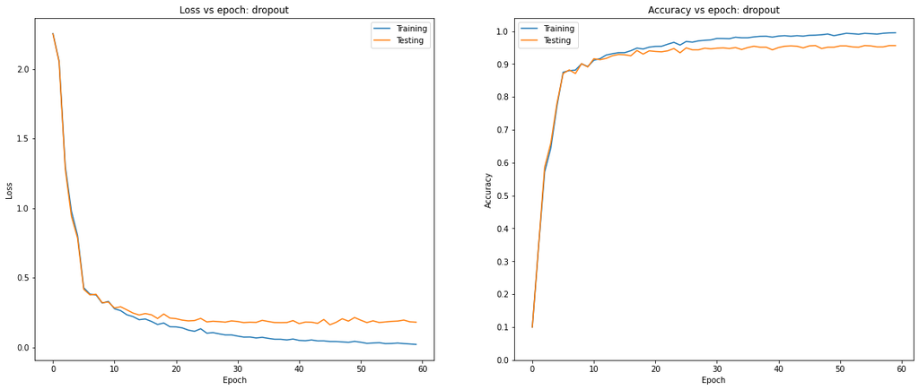

```python
plt.figure(figsize=(20,8))

plt.subplot(1,2,1)
plt.plot(loss_train_114)
plt.plot(loss_test_114)
plt.xlabel('Epoch')
plt.ylabel('Loss')
plt.title('Loss vs epoch: dropout')
plt.legend(['Training', 'Testing'])

plt.subplot(1,2,2)
plt.plot(accuracy_train_114)
plt.plot(accuracy_test_114)
plt.xlabel('Epoch')
plt.ylabel('Accuracy')
plt.yticks(np.arange(0, 1.1, 0.1))
plt.title('Accuracy vs epoch: dropout')
plt.legend(['Training', 'Testing'])

plt.show()
```

Next let us plot histograms of the activations of the units in the first hidden layer when evaluated on a batch of test data for the models with and without `dropout`.

```python
activation_unit_drop = softplus(dense(x_test[20:149], W114_drop, b114_drop))
activation_unit = softplus(dense(x_test[20:149], W112, b112))
```

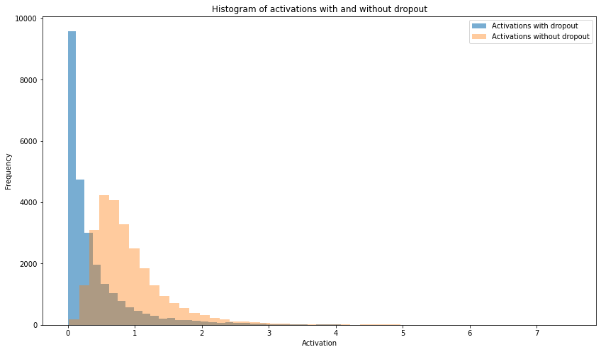

```python
plt.figure(figsize=(14,8))
plt.hist(activation_unit_drop.flatten(), alpha =0.6, label = 'Activations with dropout', bins=50)
plt.hist(activation_unit.flatten(), alpha = 0.4, label = 'Activations without dropout', bins=50)

plt.legend()
plt.xlabel('Activation')
plt.ylabel('Frequency')
plt.title('Histogram of activations with and without dropout')
plt.show()
```

In comparison to 1.1.2 we see on the training data our model with dropout reaches a loss close to 0 and accuracy of nearly 100% whereas the model in 1.1.2 does not. This suggests that this model is better at learning the data. On the testing data we see a larger gap between lines in both the loss and accuracy compared to that of 1.1.2 this suggests possible overfitting to the data in the dropout model, however, the model with dropout does still exhibit higher accuracy compared to that of 1.1.2, We also notice a plateauing behaviour in the dropout model which suggests it is quick at learning.

# 1.2 Dimensionality reduction (20 marks)

In this task we will use Principal Component Analysis (PCA) and Negative Matrix Factorisation (NMF) to denoise images from a version of the MNIST dataset corrupted by zero mean Gaussian noise.

## 1.2.1

To start we will use PCA to carry out dimensionality reduction to denoise our images. PCA is a technique used to reduce the dimension and complexity of large datasets by transforming the data to a lower dimensional space. PCA works by computing the principal components of our data which are the directions of the data which explain the most variance. For our task we will reduce the dimension of our dataset using PCA then reconstruct the original images with some of the original information lost. To perform PCA on our dataset $X$ for $k$ principal components we will have to:

1. Compute covariance matrix $C = X^T X / (n-1)$
2. Compute eigenvalues and eigenvectors of the covariance matrix $C = VLV^T$
3. Sort eigenvalues in descending order with corresponding eigenvectors
4. Compute projection into space spanned by first $k$ eigenvectors.

Let us implement this procedure below in `pca_function`.

```python
def pca_function(X,k):
    """
    Perform PCA on the data X, reducing the dimensionality to k dimensions

    Args:
        X: data matrix
        k: number of principal components

    Returns:
        X_pca: projected data matrix
        eigenvectors: eigenvectors of the covariance matrix
        eigenvalues: eigenvalues of the covariance matrix
    """

    # create covariance matrix S
    C = 1.0/(len(X)-1) * np.dot(X.T, X)

    # compute eigenvalues and eigenvectors using the eigsh scipy function
    eigenvalues, eigenvectors = linalg.eigsh(C, k, which="LM", return_eigenvectors=True)

    # sorting the eigenvectors and eigenvalues from largest to smallest eigenvalue
    sorted_index = np.argsort(eigenvalues)[::-1]
    eigenvalues=eigenvalues[sorted_index]
    eigenvectors=eigenvectors[:,sorted_index ]

    # transform our data by projection onto the eigenvectors
    X_pca = X.dot(eigenvectors)

    return X_pca, eigenvectors, eigenvalues
```

Now we have a created a function to carry out PCA for us let investigate the fraction of variance explained by PCA for a range of $m$ principal components. The eigenvalues of the covariance matrix tell us the variance along each principal component. Therefore we will find the total variance by summing all the eigenvalues then calculate the fraction of variance by summing the first $m$ components. We will note the number of principal components that explain 70%, 80% and 90% of the variance.

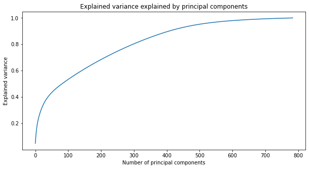

```
Number of principal components for 70% variance:  212
Number of principal components for 80% variance:  297
Number of principal components for 90% variance:  407
```

```python
# calculate the total variance
C = 1.0/(len(x_train_noisy_pca) - 1) * np.dot(x_train_noisy_pca.T, x_train_noisy_pca)
all_eigenvalues, _ = np.linalg.eig(C)
total_variance  = abs(all_eigenvalues.sum())
eigenvalues_784 = pca_function(x_train_noisy_pca, 784)[2]

# calculate the explained variance for each number of principal components
explained_variance = []
for i in range(1, 785):
    var = abs(eigenvalues_784[:i].sum())
    explained_variance.append(var/total_variance)

# plot the explained variance
plt.figure(figsize=(10, 5))
plt.plot(explained_variance)
plt.xlabel("Number of principal components")
plt.ylabel("Explained variance")
plt.title("Explained variance explained by principal components")
plt.show()

# calculate the number of principal components for 70%, 80% and 90% variance
m70 = np.where(np.array(explained_variance) >= 0.7)[0][0]
m80 = np.where(np.array(explained_variance) >= 0.8)[0][0]
m90 = np.where(np.array(explained_variance) >= 0.9)[0][0]

print("Number of principal components for 70% variance: ", m70)
print("Number of principal components for 80% variance: ", m80)
print("Number of principal components for 90% variance: ", m90)
```

Now we have plotted the fraction of variance explained by PCA as $m$ is increased let us use `imshow` to visualise the first $m=10$ principal components

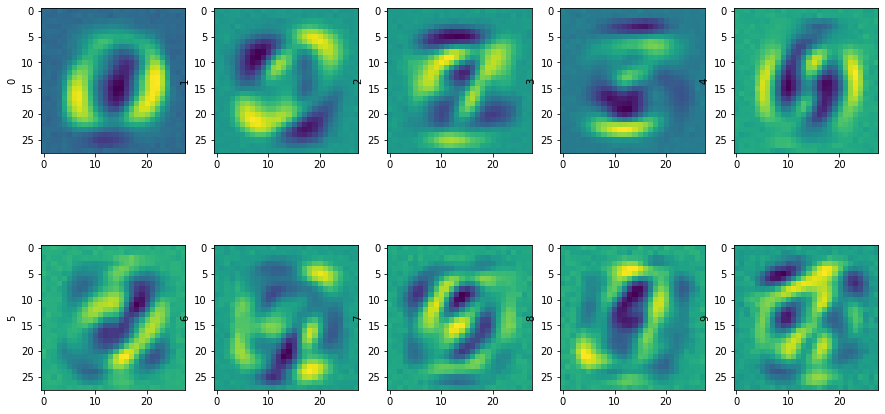

```python
# apply PCA to the data with 10 principal components
X_pca_10, eigenvectors_10, eigenvalues_10 = pca_function(x_train_noisy_pca, 10)

# plot the first 10 principal components
nrow = 2; ncol = 5;
fig, axs = plt.subplots(nrows=nrow, ncols=ncol,figsize=(15,8))

for i,ax in enumerate(axs.reshape(-1)):
    ax.imshow(eigenvectors_10[:,i].reshape([28,28]))
    ax.set_ylabel(str(i))
```

## 1.2.2

Next we will use NMF to carry out dimensionality reduction for $m=10$ dimensions onto which we will projcet the data. NMF is a matrix factorisation technique where we constrain our matrices to be non-negative, unlike PCA where our factors could be both positive and neagtive. NMF factors our data matrix $X$ into non-negative factors $W$ and $H$, however, the factorisation is not exact and is rather an approximation. That is we have $X \approx WH$ where our factors $W$ and $H$ minimise the root mean square residual between $X$ and $WH$. To compute $W$ and $H$ we will use Lee and Seung's multiplicative update rule:

$$ \mathbf{H}_{[i,j]}^{n+1}\leftarrow \mathbf{H}_{[i,j]}^{n} \frac{(( \mathbf{W}^n)^T \mathbf{X})_{[i,j]}}{((\mathbf{W}^n)^T \mathbf{W}^n \mathbf{H}^n)_{[i,j]}} $$$$ \mathbf{W}_{[i,j]}^{n+1}\leftarrow \mathbf{W}_{[i,j]}^{n} \frac{(\mathbf{X}(\mathbf{H}^{n+1})^T)_{[i,j]}}{(\mathbf{W}^n \mathbf{H}^{n+1} (\mathbf{H}^{n+1})^T)_{[i,j]}}, $$

which we run until our factors are stable. This optimisation routine requires us to initialise our matrices and to have a cost function. Our cost function will be the root mean square residuals between our original matrix $X$ and the product of our factors $WH$. We will define our $\chi ^2$ as,

$$ \chi^2 = \frac{e^⊤ \left(X \odot d \odot d \right) e}{n}, $$

where $d = X - WH$, $e$ is a vector of all ones and $n$ is the total number of elements in $X$, we also define $\odot$ to be the Hadamard product. Let us now create a `cost` function to compute our cost.

```python
def cost(X,W,H):
    """
    Compute the cost function for the NMF algorithm

    Args:
        X: data matrix
        W: factor matrix
        H: factor matrix

    Returns:
        chi2: cost function
    """

    # compute the difference between X and the dot product of W and H
    diff = X - np.dot(W, H)

    chi2 = ((X*diff) * diff).sum() / (X.shape[0]*X.shape[1])

    return chi2
```

Now we have implemented our cost function let us implement the `nmf` algorithm and we will randomly initialise our factor matrices in the function.

```python
def nmf(X, m, n_iters=200):
    """
    Perform NMF on the data X, reducing the dimensionality to m dimensions

    Args:
        X: data matrix
        m: number of components
        n_iters: number of iterations

    Returns:
        W: factor matrix
        H: factor matrix
        chi2: cost function
    """

    # set the seed for reproducibility
    np.random.seed(0)

    # m x k components matrix, usually interpreted as the coefficients, where m is the number of data
    W = np.random.rand(X.shape[0], m)

    # k x n matrix interpreted as the basis set, where n is the number of features (e.g. pixels)
    H = np.random.rand(m, X.shape[1])

    chi2 = []

    # loop over the n iterations
    for i in range(n_iters):

        # compute the update on H
        H = H * ((W.T.dot(X)) / W.T.dot(W.dot(H)))

        # compute the update on W
        W = W * ((X.dot(H.T)) / (W.dot(H.dot(H.T))))

        # compute the chi2 and append to list
        chi2.append(cost(X,W,H))

    return W, H, chi2
```

Now we have implemented our NMF algorithm let us run it on $m=10$ dimensions and plot our loss function to ensure our number of iterations is sufficient for convergence.

```python
# compute factors and cost function for NMF with 10 components
W, H, chi2 = nmf(x_train_noisy_nmf, 10, n_iters=200)
```

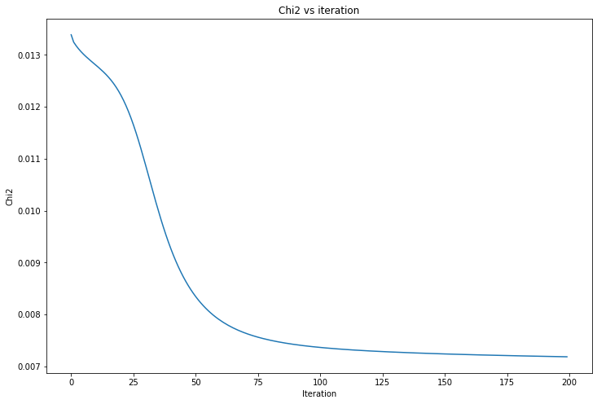

```python
plt.figure(figsize=(12,8))
plt.plot(chi2)
plt.xlabel("Iteration")
plt.ylabel("Chi2")
plt.title("Chi2 vs iteration")
plt.show()
```

Let us visualise the $m=10$ NMF components using `imshow`.

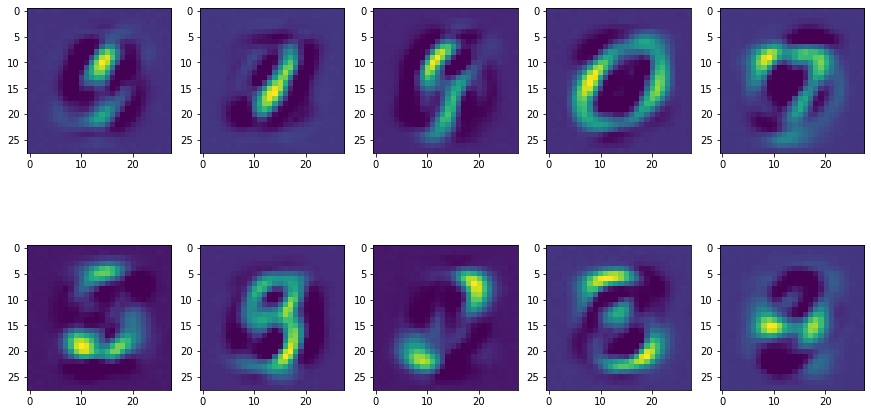

```python
nrow = 2; ncol = 5;
fig, axs = plt.subplots(nrows=nrow, ncols=ncol, figsize=(15,8))

for i,ax in enumerate(axs.reshape(-1)):
    ax.imshow(H[i,:].reshape([28,28]))
```

We see that our components obtained from PCA and NMF differ this is due to the assumptions both procedures assume. In PCA it is assumes that the data can be represented as a linear combination of orthogonal components whereas NMF assumes the data can be represented as a linear combination of non-negative components. In PCA the aim is to explain the maximal variance of components but NMF identifies the most meaningful parts of the data; therefore different components would be identified. In PCA we are given components oriented to explain the maximum variance and therefore harder to interpret due to the addition of noise whereas NMF would produce components that are more interpretable but not capture the overall variance well. Additionally, PCA is perhaps more sensitive to noise due to computations from the covariance matrix but the NMF is more robust to noise due to the constraints on non-negative factors leading to sparser, more robust representations.

## 1.2.3

It is known that both PCA and NMF can be used for image denoising. We will train PCA and NMF on the `MNIST_train_noisy.txt` dataset to find the principal and non-negative components using $m=100$

```python
X123_pca, eigenvectors_123, eigenvalues_123 = pca_function(x_train_noisy_pca, 100)
W_123, H_123, chi2_123 = nmf(x_train_noisy_nmf, 100)
```

Now that we have trained our models let us turn our attention to the `MNIST_test_noisy.txt` dataset. First let us use PCA to reconstruct our image. For PCA we have that,

$$ \mathbf{X}_{\text{train}} \approx (\mathbf{X}_{\text{projection matrix}} \cdot \text{eigenvector} \cdot \text{eigenvector}^T) \cdot \sigma_{\text{train}} + \mu_{\text{train}}, $$

where the projection matrix is of the image we wish to reconstruct, the eigenvectors of our covariance matrix and mean are from the training dataset. Now we have a formula let us implement our PCA reconstruction.

```python
def reconstruction_pca(train, test, m, train_mean, train_std):
    """
    Image reconstruction using PCA

    Args:
        train: array of training data assumed to be standardised
        test: array of testing data assumed to be standardised
        m: number of components to use
        train_mean: mean of training data
        train_std: standard deviation of training data

    Returns:
        array of reconstructed images
    """
    # compute PCA matrix, eigenvectors and eigenvalues of training data
    pca, evector, evalue = pca_function(train, m)

    # apply formula to compute reconstruction
    X_reconstructed = ((test @ evector) @ evector.T) * train_std
    return X_reconstructed + train_mean
```

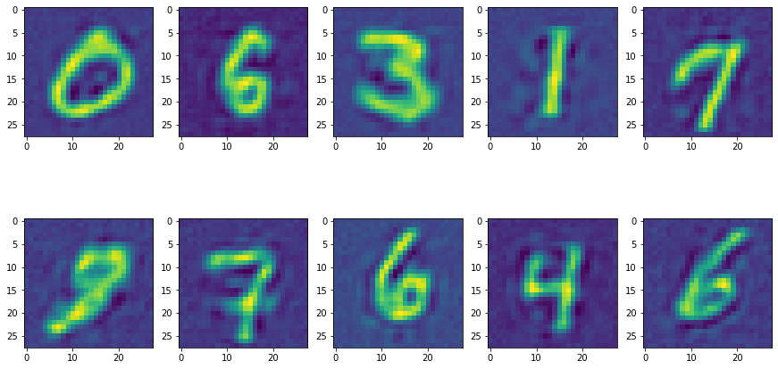

```python
reconstruct_pca = reconstruction_pca(x_train_noisy_pca, x_test_noisy_pca, 100, x_train_noisy_pca_mu, x_train_noisy_pca_std)

# visualise the reconstructed images
nrow = 2; ncol = 5;
fig, axs = plt.subplots(nrows=nrow, ncols=ncol, figsize=(15,8))

for i,ax in enumerate(axs.reshape(-1)):
    ax.imshow(reconstruct_pca[i,:].reshape([28,28]))
```

Now let us turn our attention to NMF, we have that the reconstructed image is a linear combination of the non-negative components. To do so, we will train our NMF on the training data to compute $\mathbf{H}$ our non-negative components. Next we will compute $\mathbf{W}$ by randomly initialising and then running the multiplicative update rule to compute coefficients this is done to create orthogonal components. Thus we have the formula,

$$ \mathbf{X}_{\text{test}} \approx \mathbf{W} \mathbf{H}_{\text{train}}, $$

then we undo the normalisation step to obtain our denoised test image. With this formulation let us implement below.

```python
def reconstruction_nmf(train, test, m):
    """
    Image reconstruction using NMF

    Args:
        train: array of training data
        test: array of testing data
        m: number of non-negative components

    Returns:
        array of reconstructed images
    """
    # obtain non-negative components of training data
    _, H, _ = nmf(train, m)

    # randomly initialise coefficients
    W = np.random.rand(test.shape[0], m)
    # loop to update coefficients
    for i in range(200):
        W = W * np.dot(test, H.T)/np.dot(np.dot(W, H), H.T)

    # multiple coefficients and components then undo normalisation
    X_reconstructed = (W @ H) * (np.max(test) - np.min(test)) + np.min(test)
    return X_reconstructed
```

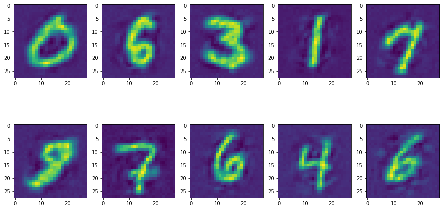

```python
reconstructed_nmf = reconstruction_nmf(x_train_noisy_nmf, x_test_noisy_nmf, 100)

# visualise the reconstructed images
nrow = 2; ncol = 5;
fig, axs = plt.subplots(nrows=nrow, ncols=ncol, figsize=(15,8))

for i,ax in enumerate(axs.reshape(-1)):
    ax.imshow(reconstructed_nmf[i,:].reshape([28,28]))
```

Now that we have implement our functions to reconstruct our images let us visualise them alongside an image from the noisy test set and the original version.

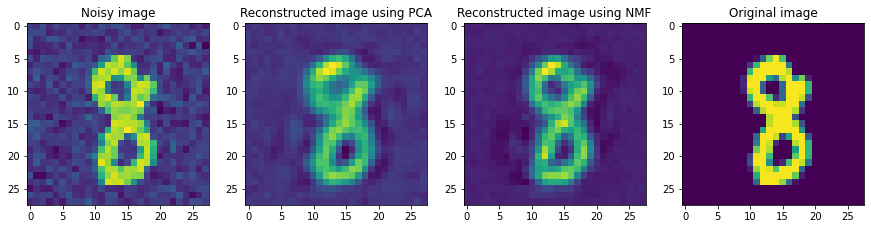

```python
fig, axs = plt.subplots(nrows=1, ncols=4, figsize=(15,40))

# visualise images
axs[0].imshow(x_test_noisy[43,:].reshape([28,28]))
axs[0].set_title('Noisy image')
axs[1].imshow(reconstruct_pca[43,:].reshape([28,28]))
axs[1].set_title('Reconstructed image using PCA')
axs[2].imshow(reconstructed_nmf[43,:].reshape([28,28]))
axs[2].set_title('Reconstructed image using NMF')
axs[3].imshow(x_test[43,:].reshape([28,28]))
axs[3].set_title('Original image')

plt.show()
```

We see that both reconstructions are interpretable with NMF being slightly clearer to interpret. We notice with PCA that the background is more similar to the noisy image whereas in NMF the background is more similar to the original image. The main difference between the two reconstructions is that in NMF the contrast between the digit and background is more defined and hence a clearer image, whereas, in PCA the image is more 'fuzzy'. However both reconstructions are ineffective in capturing the digit's colour (yellow) which can be an issue in different images and situations. Overall our results suggest the NMF is a better method for image denoising for our MNIST dataset. It is worth noting our result and the result that our $X$ is poisson distributed as described in the notes however our noise is Gaussian.

## 1.2.4

We have visualised our reconstructed images using PCA but let us now evaluate it using the Mean-Squared Error (MSE). We will compute the MSE between the reconstructed image and the images from the test sets of uncorrupted and corrupted images. Note that we re-scale by 255 within the MSE to counteract the scaling done at the start of the notebook.

```python
# compute mse between reconstructed image and test set of uncorrupted images
mse_pca_uncorrupt = np.mean((255*(x_test - reconstruct_pca))**2)
print(f'MSE between reconstruction and uncorrupted images: {mse_pca_uncorrupt}')
```

```
MSE between reconstruction and uncorrupted images: 801.6011242194652
```

```python
# compute mse between reconstructed image and test set of corrupted images
mse_pca_corrupt = np.mean((255*(x_test_noisy - reconstruct_pca))**2)
print(f'MSE between reconstruction and corrupted images: {mse_pca_corrupt}')
```

```
MSE between reconstruction and corrupted images: 1100.9829861592782
```

```python
mse_pca_uncorrupt_list = []
mse_pca_corrupt_list = []
for i in range(5,401,5):
    reconstruct_pca_i = reconstruction_pca(x_train_noisy_pca, x_test_noisy_pca, i, x_train_noisy_pca_mu, x_train_noisy_pca_std)
    mse_pca_uncorrupt_list.append(np.mean((255*(x_test - reconstruct_pca_i))**2))
    mse_pca_corrupt_list.append(np.mean((255*(x_test_noisy - reconstruct_pca_i))**2))
```

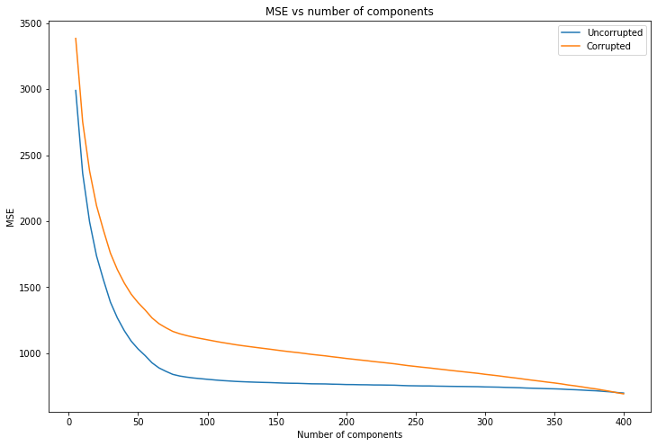

```python
plt.figure(figsize=(12,8))
plt.plot(range(5,401,5), mse_pca_uncorrupt_list, label='Uncorrupted')
plt.plot(range(5,401,5), mse_pca_corrupt_list, label='Corrupted')
plt.xlabel('Number of components')
plt.ylabel('MSE')
plt.title('MSE vs number of components')
plt.legend()
plt.show()
```

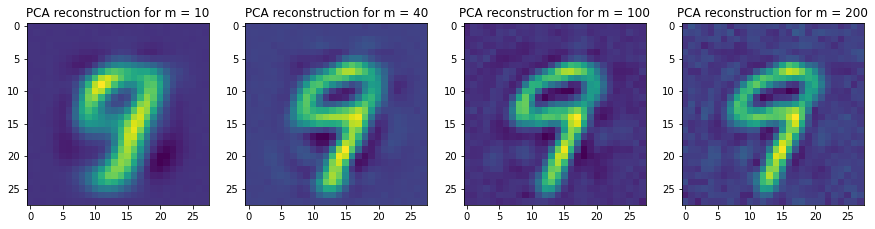

```python
m_list = [10, 40, 100, 200]

fig, axs = plt.subplots(nrows=1, ncols=4, figsize=(15,8))

for i,ax in enumerate(axs.reshape(-1)):
    reconstruct_124 = reconstruction_pca(x_train_noisy_pca, x_test_noisy_pca, m_list[i], x_train_noisy_pca_mu, x_train_noisy_pca_std)
    ax.imshow(reconstruct_124[50,:].reshape([28,28]))
    ax.set_title(f'PCA reconstruction for m = {m_list[i]}')
```

Visualising our PCA image reconstruction with a varied number of components we notice that as we increase the number of components our image becomes clearer that there is a more noticeable contrast between the digit and the background.

# 1.3 Gaussian Mixture Models (20 marks)

We will now explore clustering using Gaussian Mixture Models (GMM). Mixture models are generative models used for clustering consisting of mixture components and weights such that the marginal distribution is a convex combination of the two. We will use GMM to approximate our data and in this case our mixture components follow are Gaussian distribution. We define our GMM as,

$$ P(\boldsymbol{X}=\boldsymbol{x}) = \sum_{k=1}^K \pi_k p_k(\boldsymbol{x}|\boldsymbol{\theta})\, . $$

where $K$ is the number of clusters described by mixture components. As mentioned, each mixture component follow multivariate Gaussian distributions, $$ p_k(\boldsymbol{x}|\boldsymbol{\theta}) = {\displaystyle (2\pi )^{-k/2}\det({\boldsymbol {\Sigma }_k})^{-1/2}\,\exp \left(-{\frac {1}{2}}(\mathbf {x} -{\boldsymbol {\mu }_k})^{\!{\mathsf {T}}}{\boldsymbol {\Sigma }_k}^{-1}(\mathbf {x} -{\boldsymbol {\mu }_k})\right),} $$ where $\boldsymbol{\theta} = \{\pi_k,\mu_k, \Sigma_k \}_{k=1,2,...,K}$ is the vectors of parameters consiting of the mixture weight $\pi_k$, mixture component mean $\boldsymbol{\mu}_k$ and mixture component covariance matrix $\boldsymbol{\mu}_k$.

## 1.3.1

We will use the first 5 principal components of the PCA on the first 1000 images from `MNIST_train.csv` to perform clustering use a Gaussian Mixture Model with 10 hidden components. First let us obtain our required matrix below then create a `GMmodel` class.

```python
X131_pca, eigenvectors_131, eigenvalues_131 = pca_function(x_train_pca[:1000, :], 5)
```

```python
class GMModel:
    """Struct to define the Gas=ussian Mixture Model"""
    """:param dim: number of mixture components"""
    """:param weights: mixture weights"""
    """:param mu: mixture component means for each cluster"""
    """param sigma: mixture component covariance matrix for each cluster"""

    def __init__(self, X, dim):
        """Initialises parameters through random split of the data"""

        self.dim = dim

        """ inital weights given to each cluster are stored in phi or P(Ci=j)"""
        self.phi = np.full(shape=self.dim, fill_value=1/self.dim)

        """ initial weights given to each data point wrt to each cluster of P(Xi/Ci=j)"""
        self.weights = np.full(shape=X.shape, fill_value=1/self.dim)

        n, m = X.shape
        # dataset is divided randomly into k parts of unequal sizes
        random_row = np.random.randint(low=0, high=n, size=self.dim)

        # initial value of mean of k Gaussians
        self.mu = [X[row_index,:] for row_index in random_row]

        # initial value of covariance matrix of k Gaussians
        self.sigma = [np.cov(X.T) for _ in range(self.dim)]
```

In GMM we perform soft clustering as oppose to hard clustering using the clustering probability,

$$r_{ik}(\boldsymbol{\theta})=P(Z=k|\boldsymbol{X}=\boldsymbol{x}_i,\boldsymbol{\theta}) = \frac{\pi_k p_k(\boldsymbol{x}_i|\boldsymbol{\theta})}{\sum_{k'=1}^K \pi_{k'} p_{k'}(\boldsymbol{x}_i|\boldsymbol{\theta})},$$

which produces a distribution for each data point as it denotes the probability of data $i$ belonging to cluster $k$. Let's implement this below.

```python
def cluster_probabilities(gmm, X):
    """
    Predicts probability of each data point with respect to each cluster

    Args:
        gmm: Gaussian Mixture Model
        X: dataset

    Returns:
        weights: probability of each data point with respect to each cluster
    """

    # n has the number of rows while m has the number of columns of dataset X
    n, m = X.shape
    # Creates a n*k matrix denoting likelihood belonging to each cluster
    likelihood = np.zeros((n, gmm.dim))
    for i in range(gmm.dim):
        # likelihood of data belonging to i-th cluster
        distribution = multivariate_normal(mean=gmm.mu[i], cov=gmm.sigma[i])
        likelihood[:,i] = distribution.pdf(X)

        # weights of data belonging to i-th cluster
        numerator = likelihood * gmm.phi
        denominator = numerator.sum(axis=1)[:, np.newaxis]
        weights = numerator / denominator

    return weights
```

However, we wish to convert the soft clustering to hard clustering by taking the argmax of the distribution, this is for visualisation puroposes.

```python
def predict(gmm, X):
    """
    Performs hard clustering

    Args:
        gmm: Gaussian Mixture Model
        X: dataset

    Returns:
        cluster: cluster to which each data point belongs
    """
    weights = cluster_probabilities(gmm, X)
    return np.argmax(weights, axis=1)
```

Next we will create functions to help visualise the mixture model.

```python
def draw_ellipse(position, covariance, ax=None, **kwargs):
    """Draw an ellipse with a given position and covariance"""
    ax = ax or plt.gca()

    # Convert covariance to principal axes
    if covariance.shape == (2, 2):
        U, s, Vt = np.linalg.svd(covariance)
        angle = np.degrees(np.arctan2(U[1, 0], U[0, 0]))
        width, height = 2 * np.sqrt(s)
    else:
        angle = 0
        width, height = 2 * np.sqrt(covariance)

    # Draw the Ellipse
    for nsig in range(1, 4):
        ax.add_patch(Ellipse(position, nsig * width, nsig * height,
                             angle, **kwargs))

def plot_gmm(gmm, X, label=True, ax=None):
    ax = ax or plt.gca()
    labels = predict(gmm,X)
    if label:
        ax.scatter(X[:, 0], X[:, 1], c=labels, s=40, cmap='viridis', zorder=2)
    else:
        ax.scatter(X[:, 0], X[:, 1], s=40, zorder=2)
    ax.axis('equal')

    return ax
```

We can turn our attention to fitting the data, which we will us the EM algorithm to do so. The aim of the EM algorithm is to improve the marginal likelihood of the data by replacing the empirical averages with weighted averages corresponding to cluster probabilities. We begin by updating the mixture weights,

$$ \pi_k^{(n+1)} = \frac{1}{N}\sum_{i=1}^N r_{ik}(\boldsymbol{\theta}^{(n)}). $$

Then using the weighted means we compute the cluster means, then update the covariances,

$$ \boldsymbol{\mu}_k^{(n+1)} =\sum_{i=1}^N w_{ik}(\boldsymbol{\theta}^{(n)}) \boldsymbol{x}_i, $$$$\boldsymbol{\Sigma}_k^{(n+1)}= \sum_{i=1}^N w_{ik}(\boldsymbol{\theta}^{(n)}) (\boldsymbol{x}_i-\boldsymbol{\mu}_k) (\boldsymbol{x}_i-\boldsymbol{\mu}_k)^T.$$

We can then compute the weights from the cluster probabilities through,

$$w_{ik}(\boldsymbol{\theta}^{(n)})=\frac{r_{ik}(\boldsymbol{\theta}^{(n)})}{\sum_{i'} r_{i'k}(\boldsymbol{\theta}^{(n)})}$$

We will implement `fitStep` which will perform one iteration of the EM algorithm

```python
def fitStep(gmm, X):
    """
    Performs an EM step by updating all parameters

    Args:
        gmm: Gaussian Mixture Model
        X: dataset

    Returns:
        gmm: Gaussian Mixture Model
    """

    weights = cluster_probabilities(gmm, X)
    gmm.phi = weights.mean(axis=0)

    for i in range(gmm.dim):
        weight = weights[:, [i]]
        total_weight = weight.sum()

        gmm.mu[i] = (X * weight).sum(axis=0) / total_weight
        gmm.sigma[i] = np.cov(X.T, aweights = (weight/total_weight).flatten(), bias=True)
```

Let us visualise the space spanned by the top 2 principal components colouring each point according to their cluster using the EM algorithm

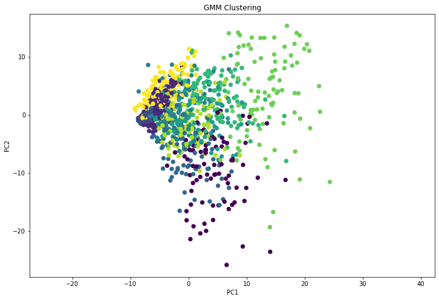

```python
# Initialise GMM

np.random.seed(912)

gmm = GMModel(X131_pca, 10)
for _ in range(200):
    fitStep(gmm, X131_pca)

# Plot GMM
plt.figure(figsize=(12,8))
plot_gmm(gmm, X131_pca)
plt.xlabel('PC1')
plt.ylabel('PC2')
plt.title('GMM Clustering')
plt.show()
```

## 1.3.2

Now let us use the class labels to visualise the space spanned by the top 2 principal components and colour each point according to their class label.

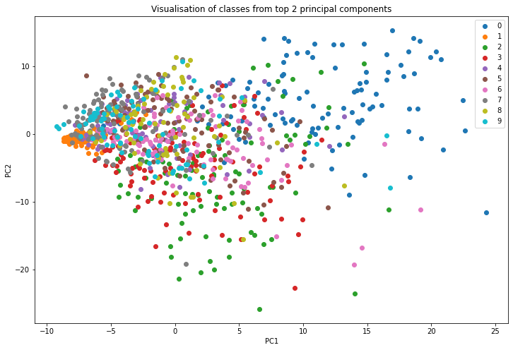

```python
plt.figure(figsize=(12,8))

# Plot GMM with labels from dataset
class_labels = y_train[:1000]
for label in np.unique(class_labels):
    plt.scatter(X131_pca[class_labels == label, 0], X131_pca[class_labels == label, 1], label=label)

plt.legend()
plt.xlabel('PC1')
plt.ylabel('PC2')
plt.title('Visualisation of classes from top 2 principal components')
plt.show()
```

Now let us map the class labels to the best fitting cluster index and use the log-likelihood to measure the fit quality.

```python
# get cluster probabilities
cluster_prob = cluster_probabilities(gmm, X131_pca)

# get log likelihood of each cluster
log_likelihood = []
for i in np.unique(class_labels):
    log_likelihood.append(np.sum(np.log(cluster_prob[class_labels == i, :] + 1e-15), axis=0))

log_likelihood = np.array(log_likelihood)
```

```python
# get cluster with maximum log likelihood for each class
label_cluster = {}
for i in range(10):
    label_cluster[i] = np.argmax(log_likelihood[i, :])
```

```python
# table for label and best-fitting cluster
df132 = pd.DataFrame(label_cluster.items(), columns=['Label', 'Cluster'])
df132.set_index('Label', inplace=True)
df132
```

| Label | Cluster |
| --- | --- |
| 0 | 7 |
| 1 | 2 |
| 2 | 0 |
| 3 | 0 |
| 4 | 4 |
| 5 | 6 |
| 6 | 5 |
| 7 | 4 |
| 8 | 6 |
| 9 | 4 |

We see that we do not have a one-to-one correspondence between labels and clusters. In fact we see some clusters being assigned to multiple labels such as cluster 4. This would suggest that in our data labels that have been assigned the same cluster have images that look similar to each other. For instance take cluster 6 which is assigned to label 5 and 8, in real life is quite common to mix up between the two digits due to bad handwriting as sloppy handwriting can lead to us connecting the ends of the number 5 which would turn it into an 8.

## 1.3.3

```python
cluster_prob_133 = cluster_probabilities(gmm, X131_pca)
```

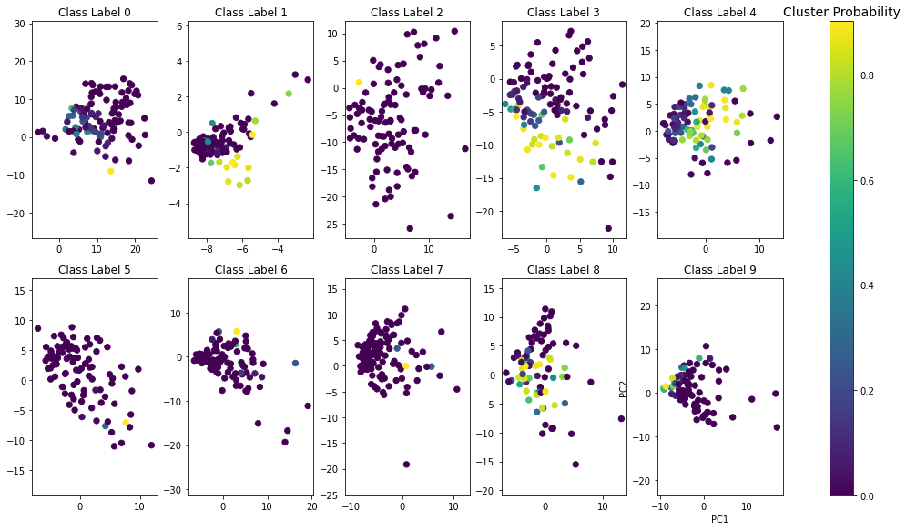

```python
nrow = 2; ncol = 5
fig, axs = plt.subplots(nrows=nrow, ncols=ncol, figsize=(15, 8))

# plot space spanned by top 2 components, colouring points according to cluster probability
for i, ax in enumerate(axs.reshape(-1)):
    sc = ax.scatter(X131_pca[class_labels == i, 0], X131_pca[class_labels == i, 1], c=cluster_prob_133[class_labels == i, i], s=40, cmap='viridis', zorder=2)
    ax.axis('equal')
    ax.set_title('Class Label {}'.format(i))

plt.tight_layout()
plt.xlabel('PC1')
plt.ylabel('PC2')
cb = fig.colorbar(sc, ax=axs.ravel().tolist())
cb.ax.set_title('Cluster Probability', fontsize=14)
plt.show()
```

## 1.3.4

Now we will retrain our GMM with 5 and 8 hidden components, computing the map of the class labels to best fitting cluster index.

```python
X134_pca, eigenvectors_134, eigenvalues_134 = pca_function(x_train_noisy_pca[:1000, :], 5)
```

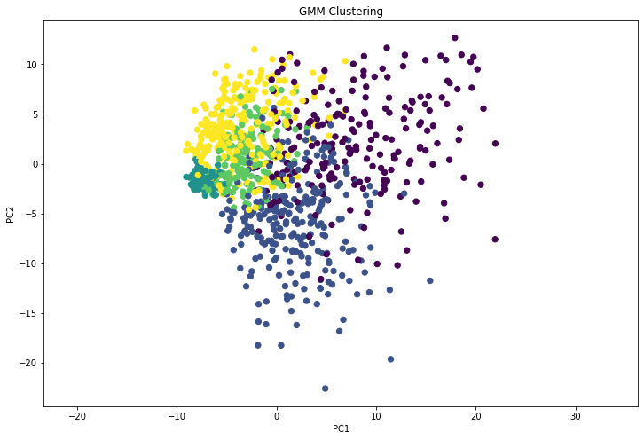

```python
np.random.seed(442)

# train GMM with 5 hidden components
gmm_134_5 = GMModel(X134_pca, 5)
for _ in range(200):
    fitStep(gmm_134_5, X134_pca)

plt.figure(figsize=(12,8))
plot_gmm(gmm_134_5, X134_pca)
plt.xlabel('PC1')
plt.ylabel('PC2')
plt.title('GMM Clustering')
plt.show()
```

```python
# compute cluster probability and log-likelihood
cluster_prob_5 = cluster_probabilities(gmm_134_5, X134_pca)
log_likelihood_134_5 = []
for i in np.unique(class_labels):
    log_likelihood_134_5.append(np.sum(np.log(cluster_prob_5[class_labels == i, :] + 1e-15), axis=0))

log_likelihood_134_5 = np.array(log_likelihood_134_5)

# obtain label-cluster map
label_cluster_5 = {}
for i in range(10):
    label_cluster_5[i] = np.argmax(log_likelihood_134_5[i ,:])
```

```python
df1345 = pd.DataFrame(label_cluster_5.items(), columns=['Label', 'Cluster'])
df1345.set_index('Label', inplace=True)
df1345
```

| Label | Cluster |
| --- | --- |
| 0 | 0 |
| 1 | 2 |
| 2 | 1 |
| 3 | 1 |
| 4 | 4 |
| 5 | 0 |
| 6 | 1 |
| 7 | 4 |
| 8 | 0 |
| 9 | 4 |

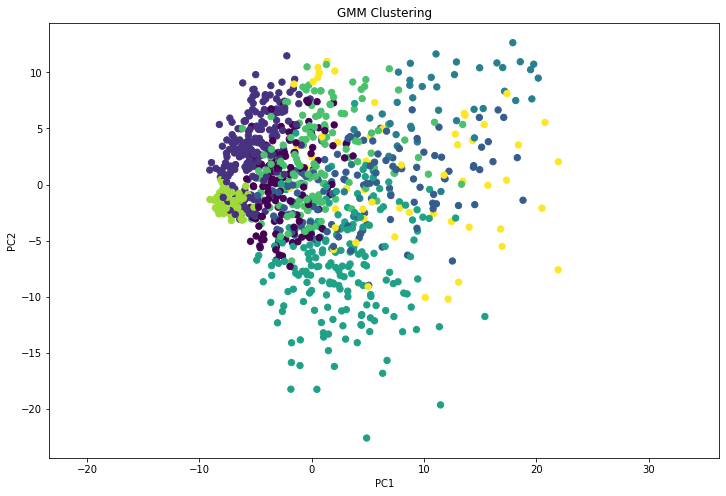

```python
np.random.seed(762)

# train GMM with 5 hidden components
gmm_134_8 = GMModel(X134_pca, 8)
for _ in range(200):
    fitStep(gmm_134_8, X134_pca)

plt.figure(figsize=(12,8))
plot_gmm(gmm_134_8, X134_pca)
plt.xlabel('PC1')
plt.ylabel('PC2')
plt.title('GMM Clustering')
plt.show()
```

```python
cluster_prob_8 = cluster_probabilities(gmm_134_8, X134_pca)

# compute cluster probability and log-likelihood
log_likelihood_134_8 = []
for i in np.unique(class_labels):
    log_likelihood_134_8.append(np.sum(np.log(cluster_prob_8[class_labels ==i , :]+1e-15), axis=0))

log_likelihood_134_8 = np.array(log_likelihood_134_8)

# obtain label-cluster map
label_cluster_8 = {}
for i in range(10):
    label_cluster_8[i] = np.argmax(log_likelihood_134_8[i ,:])
```

```python
df1348 = pd.DataFrame(label_cluster_8.items(), columns=['Label', 'Cluster'])
df1348.set_index('Label', inplace=True)
df1348
```

| Label | Cluster |
| --- | --- |
| 0 | 2 |
| 1 | 6 |
| 2 | 4 |
| 3 | 4 |
| 4 | 5 |
| 5 | 4 |
| 6 | 2 |
| 7 | 5 |
| 8 | 4 |
| 9 | 5 |

Comparing our results to the 10 component results we see similarities in which clusters are assigned to what classes for instance we see that label 7 and 9 have the same cluster assigned in all of our models. By reducing the number of hidden components we are forced to assign clusters to labels which have images that look similar to each other. This suggests that we could reduce the number of components from 10 to somewhere around 5 to 8 as we have done here.

# Task 2: Clustering and graph-based analysis (35 marks)

# Prepare Data

```python
gene_expression = pd.read_csv('gene_expression_data.csv')
gene_expression['Type'].value_counts()
```

```
BRCA    300
KIRC    146
LUAD    141
PRAD    135
COAD     78
Name: Type, dtype: int64
```

```python
X21 = gene_expression.iloc[:,:-1].to_numpy()
```

# 2.1 Clustering (15 marks)

Given our 800 x 95 matrix of gene expression levels we will implement $k$-means on these datas to find groups of samples with similar gene expression patterns.

$k$-means is an algorithm in unsuperivised learning where we aim to group $N$ samples into $k$ clusters where each sample is assigned to a cluster whose centroid is closest to, an iterative scheme which updates the centroids until convergence.

We will run $k$-means over a range of values of $k$ to find the optimal number of clusters using the average Calinski-Harabasz index over 5 initialisation for each $k$ as our score.

## 2.1.1

Before we implement $k$-means let us define our Calinksi-Harabasz index. The Calinksi-Harabasz index measures the clustering quality as a ratio of the between-cluster scatter matrix and within-cluster scatter matrix. It is defined as

$$ \text{CH}_k = \frac{\text{BCSM}}{k-1} \cdot \frac{n-k}{\text{WCSM}}, $$

where BCSM is based on the distances between clusters,

$$ \text{BCSM} = \sum_{i=1}^k n_i \cdot d(z_i, z_{\text{tot}})^2, $$

and WCSM is based on the distances within clusters,

$$ \text{WCSM} = \sum_{i=1}^{k} \sum_{x \in c_i} d(x, z_i)^2, $$

where $n$ is the total number of points, $k$ is the number of clusters, $z_i$ is the center of cluster $c_i$, $n_i$ is the number of points in $c_i$ and $d(x,y)$ is the Euclidean distance.

```python
def calinskiHarabaszIndex(X, labels, centroids, k):
    """
    Compute the Calinski-Harabasz index for a given number of clusters

    Args:
        X: array of data points
        labels: array of cluster labels
        centroids: array of cluster centroids
        k: number of clusters

    Returns:
        Calinski-Harabasz index for the given number of clusters
    """

    # compute BCSM
    bcsm = np.sum([len(X[labels == i]) * np.sum((centroids[i] - np.mean(X, axis = 0)) ** 2) for i in range(k)])

    # compute WCSSM
    wcsm = np.sum([np.sum((X[labels == i] - centroids[i]) ** 2) for i in range(k)])

    # compute Calinksi-Harabasz index
    return ((bcsm * (len(X) - k))) / ((k - 1) * (wcsm))
```

Now we have created a function that computes the Calinksi-Harabasz index we can implement $k$-means with our score function.

```python
def k_means(X, k, max_iter=30, prt=False):
    """
    Perform k-means clustering on a given dataset

    Args:
        X: array of data
        k: number of clusters
        max_iter: maximum number of iterations
        prt: print the number of iterations

    Returns:
        labels: array of cluster labels
        centroids: array of cluster centroids
    """

    n_samples, n_features = X.shape

    new_labels = np.zeros(len(X))
    difference = 0

    # labels: assign every sample to a cluster at random
    labels = np.random.randint(low=0, high=k, size=n_samples)
    X_labels = np.append(X, labels.reshape(-1,1), axis=1)

    # computing the centroids of each of the k clusters
    centroids = np.zeros((k, n_features))
    for i in range(k):
        # if no samples assigned to a cluster then assign centroid to mean of all samples
        if (labels == i).any() == False:
            centroids[i] = np.mean(X, axis=0)[0:n_features]
        else:
            centroids[i] = np.mean([x for x in X_labels if x[-1]==i], axis=0)[0:n_features]

    # k-means algorithm
    for i in range(max_iter):
        if prt == True:
            print('Iteration:', i)
        # distances: between data points and centroids
        distances = np.array([np.linalg.norm(X - c, axis=1) for c in centroids])
        # new_labels: computed by finding centroid with minimal distance
        new_labels = np.argmin(distances, axis=0)

        if (labels==new_labels).all():
            # labels unchanged
            labels = new_labels
            if prt == True:
                print('Labels unchanged! Terminating k-means.')
            break
        else:
            # labels changed
            # difference: percentage of changed labels
            difference = np.mean(labels!=new_labels)
            if prt == True:
                print('%4f%% labels changed' % (difference * 100))
            labels = new_labels
            for c in range(k):
                # update centroids by taking the mean over associated data points
                if (labels == c).any():
                    centroids[c] = np.mean(X[labels==c], axis=0)

    return centroids, labels
```

Now we have created functions for the score and $k$-means let us implement $k$-means over a range of $k$ to find the optimal $k$ and plot the behaviour between the number of clusters and Calinski Harabasz index. After we find the optimal $k$ let us see the size of each cluster with the optimal $k$.

```
Optimal k: 4
Cluster 1: 122 samples
Cluster 2: 135 samples
Cluster 3: 400 samples
Cluster 4: 143 samples
```

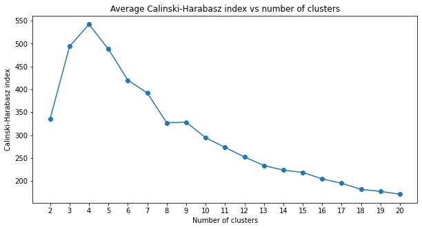

```python
np.random.seed(52)

# empty list to store the average Calinski-Harabasz index for each number of clusters
ch_score = []
for k in range(2, 21):
    ch_score_5 = []
    for j in range(5):
        centroid, label = k_means(X21, k)
        ch_score_5.append(calinskiHarabaszIndex(X21, label, centroid, k))
    ch_score.append(np.mean(ch_score_5))

print(f'Optimal k:', np.argmax(ch_score)+2)

# print the number of samples in each cluster
label, count = np.unique(k_means(X21, np.argmax(ch_score)+2)[1], return_counts=True)
for i in range(len(label)):
    print(f'Cluster {label[i]+1}: {count[i]} samples')

plt.figure(figsize=(10,5))
plt.plot(range(2,21), ch_score, marker='o')
plt.xlabel('Number of clusters')
plt.xticks(np.arange(2, 21, 1))
plt.ylabel('Calinski-Harabasz index')
plt.title('Average Calinski-Harabasz index vs number of clusters')
plt.show()
```

We see from our plot that our optimal $k= 4$ is different to the number of sample tumour types on in our dataset.

## 2.1.2

Now we have obtained our optimal $k$ we would like to evaluate the consistency between our clustering obtained through $k$-means and the assigned classes. To do so we will compute the homogeneity score which measures the extent to which the data points in one cluster belong to the same class. The homogeneity score given a set of classes $C$ and clusters $K$ is given by,

$$ \text{Homogeneity Score} = 1 - \frac{H(C|K)}{H(C)}. $$

We define the conditional entropy $H(C|K$ as, $$ H(C|K) = - \sum_{k=1}^{|K|} \sum_{c=1}^{|C|} \frac{a_{ck}}{N} \log\left(\frac{a_{ck}}{\sum_{c=1}^{|C|} a_{ck}} \right), $$ and the entropy $H(C)$ as, $$ H(C) = - \sum_{c=1}^{|C|} \frac{\sum_{k=1}^{|K|} a_{ck}}{N} \log \left( \frac{\sum_{k=1}^{|K|} a_{ck}}{N} \right), $$ where $|C|$ and $|K|$ are the sizes of $C, K$, $N$ is the total number of data points, $a_{ck}$ is the number of data points in class $c$ and assigned to cluster $k$.

Before we implement a function to compute the homogeneity score we will obtain the correct class label for each data point and assign a numeric value for each tumour type.

```python
y21_true = gene_expression['Type'].to_numpy()
y21_pred = k_means(X21, 4)[1]

label_map = {'BRCA' : 0, 'COAD' : 1, 'KIRC' : 2, 'LUAD' : 3, 'PRAD' : 4}
y21_true_numeric = gene_expression['Type'].map(label_map)
```

Now that we have our correct class label and assigned a numeric value to each let us define a function to compute the homogeneity score.

```python
def homogeneityScore(y_true, y_pred):
    """
    Compute the homogeneity score for a given clustering

    Args:
        y_true: array of true labels
        y_pred: array of predicted labels

    Returns:
        homogeneity score for the given clustering
    """

    # empty array to store counts of each class in each cluster
    a = np.zeros((len(np.unique(y_true)), len(np.unique(y_pred))))

    # for loop to count the number of samples in each cluster for each class
    for i in range(len(y_true)):
        a[y_true[i]][y_pred[i]] += 1

    # sum over rows and columns to get the number of samples in each class and cluster
    class_count = np.sum(a, axis=1)
    cluster_count = np.sum(a, axis=0)

    # compute conditional entropy
    conditional_entropy = 0
    for k in range(len(np.unique(y_pred))):
        for c in range(len(np.unique(y_true))):
            # if no samples in a cluster then skip
            if a[c][k] != 0:
                conditional_entropy += a[c][k]/len(y_true) * np.log((a[c][k] + 1e-20)/cluster_count[k])

    # compute entropy
    entropy = 0
    for c in range(len(np.unique(y_true))):
        entropy += np.sum(class_count[c])/len(y_true) * np.log(np.sum(class_count[c])/len(y_true))

    homogeneity = 1 - conditional_entropy/entropy

    return homogeneity
```

Now we have our function to compute the homogeneity score let us compute the homogeneity score for our optimal $k$.

```python
print('Homogeneity score for k = 4:', homogeneityScore(y21_true_numeric, y21_pred))
```

```
Homogeneity score for k = 4: 0.6653242487126453
```

The homogeneity score suggests that on average 66% of the data points in each cluster are of the same category. Our score indicates that our algorithm has produced clusters that are homogeneous, however, there is room for improvement. In relation to our tumour types we originally had 5 tumour types, however, our optimal number of clusters was 4 which is inconsistent. This suggests we should re-evaluated our index or look into our data.

# 2.2 Graph-based analysis (20 marks)

Now we will turn to graph-based analysis to study the structure of the network of co-regulation among genes that can be constructed from these expression data.

## 2.2.1

First we will compute the matrix of connected correlations between columns and use this matrix as our similarity matrix to construct a graph that links genes. Then we will set diagonal terms to 0 and perform thresholding with a level of 0.75 on the absolute value. Then we will take the remaining matrix as our adjacency matrix $A$ of a weighted graph describing gene co-expression.

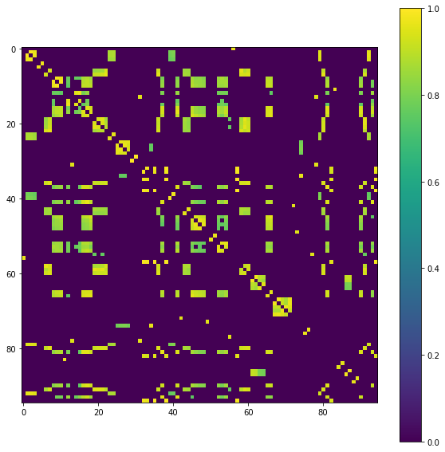

```python
# compute the correlation matrix of the data
A = np.corrcoef(X21.T)
# set the diagonal to 0
np.fill_diagonal(A, 0)
# set the absolute value of the correlation matrix to 0 if it is less than 0.75
A[abs(A)<0.75] = 0

# visualise adjacency matrix
plt.figure(figsize=(10,10))
plt.imshow(A)
plt.colorbar()
plt.show()
```

## 2.2.2

Now we will compute the degree centrality of each node in our network then print the 5 genes with the highest degree centrality.

```python
# compute the degree centrality of each node
degree_centrality = np.sum(A, axis=0)/np.sum(A)
# print the top 5 nodes with the highest degree centrality
pd.DataFrame({'Node':np.argsort(degree_centrality)[-5:][::-1], 'Degree Centrality':np.sort(degree_centrality)[-5:][::-1]})
```

|  | Node | Degree Centrality |
| --- | --- | --- |
| 0 | 17 | 0.026873 |
| 1 | 41 | 0.025935 |
| 2 | 16 | 0.025378 |
| 3 | 81 | 0.025231 |
| 4 | 90 | 0.024870 |

## 2.2.3

Next we will construct the symmetric normalised Laplacian of the graph,

$$ L = I - D^{-1/2}AD^{-1/2}. $$

```python
# compute symmetric normalised Laplacian
degree = np.sum(A, axis=0)
weighted_degree_sqrt = 1.0/np.sqrt(degree)
D_inv_sqrt = np.diag(weighted_degree_sqrt)
L_norm = np.eye(A.shape[0]) - D_inv_sqrt.dot(A.dot(D_inv_sqrt))
```

Now we will compute eigenvalues and eigenvectors of the symmetric normalised Laplacian, plotting the spectrum of eigenvalues and marking the gap between eigenvalues of 0 and not 0 due to numerical rounding.

```python
# compute eigenvalues of the symmetric normalised Laplacian and sort them in ascending order
eigenvalues, eigenvectors = linalg.eigsh(L_norm, k=94, which='SM')
# find the index of the first eigenvalue that rounds down to 0
cut_off = np.where(eigenvalues < 1e-10)[0][-1]
```

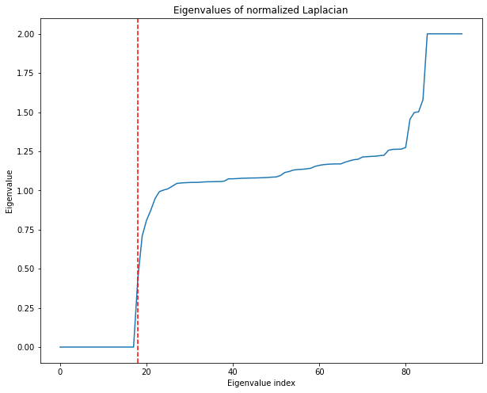

```python
# plot the eigenvalue spectrum
plt.figure(figsize=(10, 8))
plt.plot(eigenvalues)
plt.axvline(x=cut_off+1, color='r', linestyle='--')
plt.xlabel('Eigenvalue index')
plt.ylabel('Eigenvalue')
plt.title('Eigenvalues of normalized Laplacian')
plt.show()
```

```python
print(f'Number of zero eigenvalues: {cut_off+1}')
```

```
Number of zero eigenvalues: 18
```

Since we have 18 eigenvalues of value 0 this means our graph contains 18 disconnected components.

## 2.2.4

Let us define a 95 x 18 matrix $U$ containing the 18 eigenvectors of the symmetric normalised Laplacian corresponding to 0 eigenvalues as columns. Then we will create a new matrix $T$ of size 95 x 18 by normalising the rows of $U$ to 1,

$$ T_{ij} = \frac{U_{ij}}{\sqrt {\sum_{k}U_{ik}^2}}. $$

```python
U = eigenvectors[:,:18]
T = U/(np.sqrt(np.sum(U**2, axis=1)[:, np.newaxis]))
```

Using our normalised matrix T we will apply $k$-means to the matrix over a range of $k$. We will use the normalised within-cluster distance and the elbow method to set the appropiate value of $k$. The within-cluster distance is defined as

$$ W(C) = \frac{1}{2} \sum_{l=1}^{k} \frac{1}{|c_l|} \sum_{i, \ j \in c_l} ||X^{(i)} - X^{(j)}||^2 = \sum_{l=1}^{k} \sum_{i \in c_l} ||X^{(i)} - \textbf{m}_l||^2 $$

which measures the distances between points in a given cluster.

```python
def within_cluster_distance(X, k):
    """
    Compute the within-cluster distance for a given clustering

    Args:
        X: data matrix
        k: number of clusters

    Returns:
        within-cluster distance for the given clustering
    """
    # compute the centroids and labels for the given clustering
    centroid, label = k_means(X, k)
    # compute the within-cluster distance
    W = 0
    for l in range(k):
        W += np.sum(np.linalg.norm(X[label==l] - centroid[l])**2) # sum of 2-norms
    return W
```

```python
np.random.seed(3)

# empty list to store the within-cluster distance for each number of clusters
dist = []
for k in range(2, 50):
    dist_min = []
    for j in range(50):
        dist_min.append(within_cluster_distance(T, k))
    dist.append(min(dist_min))
```

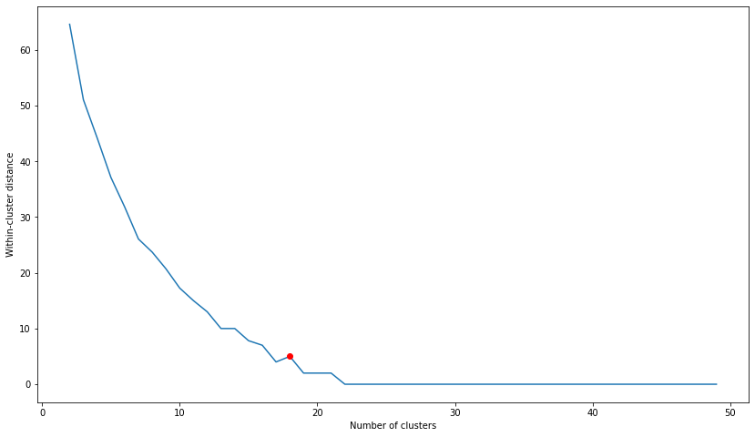

```python
plt.figure(figsize=(14, 8))
plt.plot(range(2,50), dist)
# plot a red circle at the elbow
plt.plot(18, dist[18-2], 'ro')
plt.xlabel('Number of clusters')
plt.ylabel('Within-cluster distance')
plt.show()
```

Examining our plot and using the elbow method we choose the optimal number of clusters as $k=18$. Let us now examine the cluster sizes and interepret them.

```python
np.random.seed(19)

labels_224 = k_means(T, 18)[1]

# empty dictionary to store the number of samples in each cluster
clust = {}
for c, count in zip(np.unique(labels_224), np.unique(labels_224, return_counts=True)[1]):
    clust[c] = count
    print(f'Cluster {c}: {count} samples')

# find the cluster with the most samples
big_clust = max(clust, key=clust.get)
```

```
Cluster 0: 2 samples
Cluster 2: 2 samples
Cluster 3: 6 samples
Cluster 4: 2 samples
Cluster 7: 23 samples
Cluster 8: 9 samples
Cluster 9: 4 samples
Cluster 10: 6 samples
Cluster 11: 7 samples
Cluster 12: 2 samples
Cluster 13: 2 samples
Cluster 14: 5 samples
Cluster 15: 4 samples
Cluster 16: 5 samples
Cluster 17: 16 samples
```

## 2.2.5

Considering the biggest cluster identified in $\mathbf{2.2.4}$ let us re-calculate the normalised Laplacian of the cluster and the corresponding eigenvalues and eigenvectors.

```python
# compute the adjacency matrix of the largest cluster
A_225 = A[labels_224 == big_clust][:, labels_224 == big_clust]
degree_centrality_225 = np.sum(A_225, axis=0)/np.sum(A_225)

# dictionary to track genes from original adjacency matrix to corresponding new adjacency matrix
A_225_idx_original = {}
for i in range(clust[big_clust]):
    A_225_idx_original[i] = np.where(labels_224 == big_clust)[0][i]

# compute symmetric normalised Laplacian
degree_225 = np.sum(A_225, axis=0)
weighted_degree_sqrt_225 = 1.0/np.sqrt(degree_225)
D_inv_sqrt_225 = np.diag(weighted_degree_sqrt_225)
L_norm_225 = np.eye(A_225.shape[0]) - D_inv_sqrt_225.dot(A_225.dot(D_inv_sqrt_225))

# compute the second smallest eigenvalue and eigenvector of the symmetric normalised Laplacian
eigenvals_225, eigenvecs_225 = linalg.eigsh(L_norm_225, 2, which="SM", return_eigenvectors=True)

second_eigenvec_225 = eigenvecs_225[:,1]
```

Using the second eigenvalue (spectral gap) we will use the corresponding eigenvector (Fiedler vector) to perform spectral clustering. We will set negative values to 0 and positive values to 1. This will results in a binary partition of the subgraph. Then we will use histograms to visualise the magnitude of the network links within each partition and across the 2 partitions.

```python
# partition the nodes into 2 clusters based on the sign of the second eigenvector
spectral_partition = second_eigenvec_225
spectral_partition[spectral_partition < 0] = 0
spectral_partition[spectral_partition > 0] = 1

# compute the adjacency matrices of the two clusters
idx0 = np.where(spectral_partition == 0)
idx1 = np.where(spectral_partition == 1)

# np.squeeze to remove extra dimension
A_225_0 = np.squeeze(A_225[idx0][:, idx0])
A_225_1 = np.squeeze(A_225[idx1][:, idx1])
```

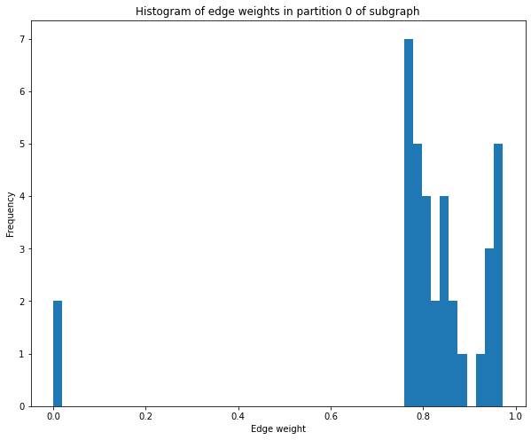

```python
plt.figure(figsize=(10, 8))
plt.hist(A_225_0[np.triu_indices((A_225_0.shape)[0], k=1)], bins=50)
plt.xlabel('Edge weight')
plt.ylabel('Frequency')
plt.title('Histogram of edge weights in partition 0 of subgraph')
plt.show()
```

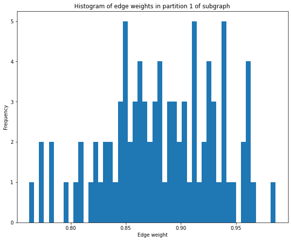

```python
plt.figure(figsize=(10, 8))
plt.hist(A_225_1[np.triu_indices((A_225_1.shape)[0], k=1)], bins=50)
plt.xlabel('Edge weight')
plt.ylabel('Frequency')
plt.title('Histogram of edge weights in partition 1 of subgraph')
plt.show()
```

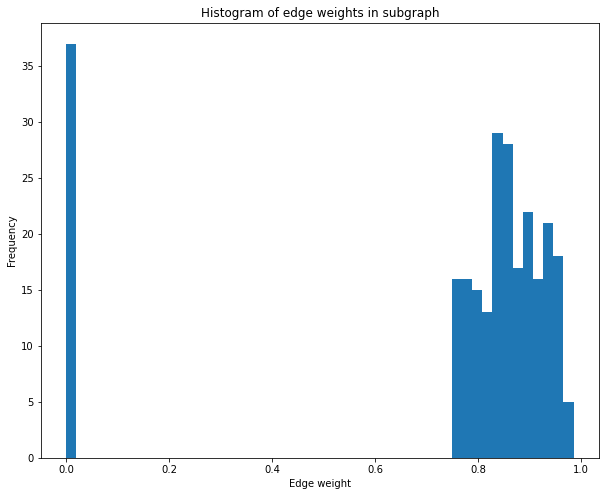

```python
plt.figure(figsize=(10, 8))
plt.hist(A_225[np.triu_indices((A_225.shape)[0], k=1)], bins=50)
plt.xlabel('Edge weight')
plt.ylabel('Frequency')
plt.title('Histogram of edge weights in subgraph')
plt.show()
```

## 2.2.6

Considering the subgraph from $\mathbf{2.2.5}$ we will compute the degree centrality of the nodes in the subgraph and print the index of the top 5 ranking ones.

```python
degree_centrality_225 = np.sum(A_225, axis=0)/np.sum(A_225)
original_idx = [A_225_idx_original[idx] for idx in np.argsort(degree_centrality_225)[-5:][::-1]]
pd.DataFrame({'Node': original_idx, 'Degree Centrality': np.sort(degree_centrality_225)[-5:][::-1]})
```

|  | Node | Degree Centrality |
| --- | --- | --- |
| 0 | 17 | 0.052890 |
| 1 | 41 | 0.051044 |
| 2 | 16 | 0.049948 |
| 3 | 81 | 0.049657 |
| 4 | 90 | 0.048948 |

We see that the 5-top ranking genes based on degree centrality in our subgraph are the same as the ones obtained in our full graph albeit with roughly double the degree centrality. This results suggests that either the subgraph obtained is not significantly different to the full graph or that we have a dense subgraph within our graph which is supported after analysis of our histogram. Furthermore this could suggest that nodes with the most links are also linked to each other.